# Household Artefacts

Meredith Osmond and Malcolm Ross

## 1. Introduction

The artefacts considered here are mainly household items, used in the gathering and storage of food, in the construction and maintenance of dwellings and gardens, and those used for personal adornment. Some of the items—earthenware pots, stone adzes and axes, bone needles, bone and shell ornaments, and stone bark-cloth beaters—have provided archaeologists with data that permit dating. Those made of perishable materials—such as leaf baskets, string bags, mats and bamboo knives—seldom leave any trace in the archaeological record. For these we are dependent on linguistic reconstruction interpreted in the light of current ethnographic practice.[^1]:

Artefacts are organised under the following headings: (1) containers; (2) mats and cordage; (3) tools; (4) items of body decoration and clothing, and (5) instruments of communication and music. Terms for relevant processes are included. Thus, within the section on mats and cordage we have included terms for weaving, making thread, sewing, and for needle and twine. Often the term for a tool is derived from the verb denoting the activity of using it.

## 2. Containers

### 2.1. Pottery containers

Pottery is one of the more distinctive features of the Lapita culture, here held to coincide with and thus be an integral marker of the early dispersal of Proto Oceanic.[^2]: Pottery manufacture in Oceania is geographically discontinuous. By no means all Oceanic speakers make pottery. Obviously, pottery can only be made where suitable clay is available, but its availability is no guarantee that pottery will be manufactured. Nor is its absence from the immediate locality a guarantee that pottery will not be made: the Gumawana speakers of the Amphlett group transport their clay some distance by sea from Fergusson Island. As a result of this discontinuity, pots were traditionally important trade items. A linguistic spin-off of this trade is that words for pots are not infrequently loan words, especially in the languages of the people who are not potters.

Ross (1996c:69) writes that most Oceanic languages have quite a simple pot terminology with three or four main terms.

> There is generally a term for cooking pot, which often also doubles as the term for pottery in general … Secondly, there is a term for water pot or water jar. Thirdly, there is a term for a bowl or dish with a variety of functions, and finally a term for a frying dish or frying pan (in some societies the object itself is actually the large sherd of a broken pot).

There is fair agreement across Oceanic languages about the structure of the terminology—Ross provides evidence from NNG, PT, Admiralties and Fijian languages which all have terms (not necessarily cognate) for pot (generic), cooking pot, water jar, bowl/dish and frying pan (see Figure 4)—and we have PMP reconstructions in support of corresponding POc terms. However, our cognate sets are disappointingly small. Of our reconstructions, the cooking pot/generic term is the most soundly based.

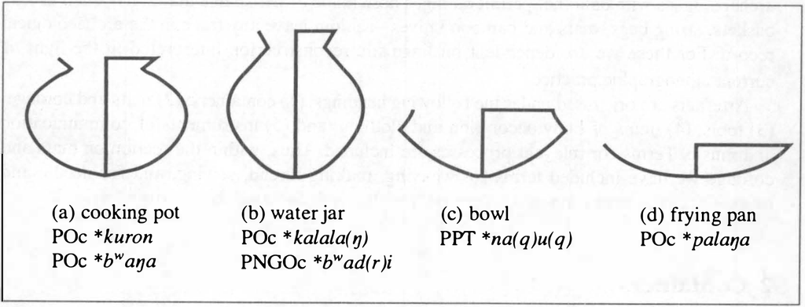

#### 2.1.1. Cooking pot

| **PMP** |  | *kuDen | ‘clay cooking pot’ (Blust 1982) |
| --- | --- | --- | --- |
| **POc** |  | *kuron | ‘earthernware pot’ |
| Adm | Drehet | *kuŋ* | ‘earthernware pot’ |
| Adm | Nyindrou | *kun* | ‘earthernware pot’ |
| NNG | Kove | *ulo* | ‘cooking pot, boil (in water)’ |
| NNG | Numbami | *ulaŋa* | ‘earthernware pot’ |
| NNG | Adzera | *gur* | ‘earthernware pot’ |
| PT | Molima | *ʔulena* | ‘earthernware pot’ |
| PT | Misima | *ulun* | ‘earthernware pot’ |
| PT | Motu | *uro* | ‘earthernware pot’ |
| MM | Bali | *ɣulon(i)* | ‘boil (in water)’ |
| MM | Ramoaaina | *kuro* | ‘earthernware pot’ |
| NCV | Wusi | *uro* | ‘earthernware pot’ |
| Fij | Bauan | *kuro* | ‘earthernware pot’ |
| Pn | Samoan | *ʔulo* | ‘pot, cauldron’ |

#### 2.1.2. Water jar

The best candidate for ‘water jar’ is POc *kalala(ŋ), reconstructed on the basis of Proto WMP *kalalaŋ ‘narrow-necked water jar’ (Tagalog *kalalaŋ* ‘narrow-necked water jug’; Blust 1980b). However, only one Oceanic reflex, in the PT language Iduna, has been found: *kalala* ‘cooking pot made in Wedau’. Even this reflex is problematic, since POc *l is reflected as Iduna *n* in directly inherited items, and we must therefore assume that the item has been borrowed, as its gloss would imply.

Another possible, PNGOc, term for water jar is *bʷad(r)i, for which the evidence is given below. All reflexes except one are from the north coast of New Guinea, and mean ‘pot (generic), cooking pot’, where they have ousted reflexes of POc *kuron in this role, but there is evidence that this is the result of post-Proto Oceanic genericisation. The characteristic Oceanic cooking pot and water jar are quite similar in form, differing only in the narrowness of the neck of the water jar, so that genericisation of the water jar term is quite likely. The facts that the one non-north coast term, from Misima, means ‘water pot’ and that there are indications (in Mindiri and Bilibil) that reflexes of *bʷad(r)i also mean ‘water pot’ suggest that this was its original meaning.

| **PNGOc** |  | *bʷad(r)i | ‘k.o. large pot, possibly for water storage’ |
| --- | --- | --- | --- |
| NNG | Lukep | *bor* | ‘pot’ |
| NNG | Roinji | *buari* | ‘cooking pot’ |
| NNG | Mindiri | *badi(n)* | ‘water pot’ |
| NNG | Bilibil | *bodi* | ‘cooking pot’ |
| NNG | Bilibil | *(yu)bodi* | ‘pot for water storage and carrying’ (*yu* ‘water’) |
| NNG | Takia | *bod* | ‘clay, clay pot’ |
| NNG | Manam | *boadi* | ‘pot, cooking vessel’ |
| NNG | Kaiep | *biar* | ‘generic name for pots’ |
| NNG | Kairiru | *buar̃* | ‘cooking pot’ |
| NNG | Ulau-Suain | *buad* | ‘cooking pot’ |
| NNG | Tumleo | *pier* | ‘cooking pot, pot (generic)’ |
| PT | Misima | *(ulun)bʷal* | ‘water pot about 30 cm high’ (*ulun* ‘clay pot’) |

cf. also:

| PT | Motu | *hodu* | ‘narrow-necked water pot’ |
| --- | --- | --- | --- |
| PT | Lala | *vodu* | ‘narrow-necked water pot’ |

The Motu and Lala items are either borrowed or simply bear a chance resemblance to this set.

#### 2.1.3. Frying pan

The best candidate for ‘frying pan’, POc *palaŋa, has been noted by Blust (ACD). Again, Oceanic reflexes are not plentiful, but here there can hardly be any doubt that they reflect the PMP term.

| **PMP** |  | *balaŋa | ‘shallow earthenware cooking pot or pan’ (ACD) |
| --- | --- | --- | --- |
| **POc** |  | *palaŋa | ‘frying pan’ |
| NNG | Bilibil | *(bodi) palan* | ‘sago frying bowl, made by cutting down a broken pot’ (*bodi* ‘cooking pot’) |
| NNG | Gedaged | *palaŋ* | ‘potsherd, used to render fat and to cook oil; frying pan, shallow roaster’ |

#### 2.1.4. Large cooking pot

One other Proto Oceanic term for a type of pot is reconstructable, namely *bʷaŋa. This seems to have referred to a large pot, perhaps a communal cooking pot:

| **PMP** |  | *báŋaq | ‘pot, cooking vessel’ |
| --- | --- | --- | --- |
| **POc** |  | *bʷaŋa | ‘k.o. large pot’ |
| **PNGOc** |  | *(kuron) bʷaŋa | ‘communal cooking pot’ |
| NNG | Adzera | *(gur) baŋa* | ‘common cooking pot for meat’ (*gur* ‘clay pot’) |
| PT | Misima | *(ulun) bʷana* | ‘cooking pot about 60 cm high, used as a community cooking pot’ (*ulun* ‘clay pot’) |

#### 2.1.5. Dish

We have been unable to reconstruct a POc term for a bowl or dish. Indeed, the only term we have found reflected over quite a large area is PPT *na(q)u(q). The meanings of its reflexes indicate that it meant ‘dish’. In a number of PT languages it has come to mean ‘cooking pot’, but this is not surprising if it is recognised that in south-east (but not central) Papua, the typical Oceanic cooking pot with its restricted spherical form has been frequently replaced by pots with an unrestricted, dish-like form. In Gumawana, an important pot-making centre in the Amphletts, *no*, reflecting *na(q)u(q), has been genericised to mean ‘pot’ and is the first element in a number of pot types listed in Olsen’s dictionary: *nobadala*, *nogaiga*, *nokaokao*, *nokunu*, *nopaeva*, *nosipoma*. All of these are apparently dish-like in form. Some reflexes of *naquq are listed below. The crucial reflexes for determining the meaning of *na(q)u(q) are those from central Papua-Hula, Motu and Kuni—where Oceanic restricted pot forms remain the norm, and *naɣu*/*nau* clearly refers only to dishes.

| **PPT** |  | *na(q)u(q) | ‘clay dish’ |
| --- | --- | --- | --- |
| PT | Gumawana | *no* | ‘clay pot’ |
| PT | Molima | *nau(kai)* | ‘wooden dish’ (*kai* ‘wood’) |
| PT | Iduna | *nauʔa* | ‘dish, bowl, plate’ |
| PT | Are | *nau* | ‘cooking pot’ |
| PT | Muyuw | *no(kay)* | ‘large wooden dish’ (*kay* ‘wood’) |
| PT | Sudest | *noɣa* | ‘(wooden) dish’ |
| PT | Hula | *naɣu* | ‘clay plate used by Motu and Mailu people’ |
| PT | Motu | *nau* | ‘shallow open dish for serving’ |
| PT | Kuni | *nau* | ‘clay dish’ |

Only the Hula form reflects a possible medial *-q-. Since Hula sometimes adds a nonetymological *-y-* between vowels, *-q- cannot be reconstructed with certainty. Final *-q is reflected in Iduna and Sudest, but not in Gumawana, Molima or Are, where a reflex would also be expected. These uncertainties raise the possibility that this term is cognate with the forms attributed to POc *napu ‘steam (?), boil (7)’ (Ch. 6, §3.4).

#### 2.1.6. Lid

Both cooking pots and narrow-necked water jars may have utilised lids. In addition to those terms glossed ‘plug, stopper’, which are included with coconut or bamboo water carriers, we have terms referring rather to ‘lid’ or ‘cover’:

| **PMP** |  | *tub-tub | ‘close, cover’ (Mills 1981) |
| --- | --- | --- | --- |
| **POc** |  | *tutup | ‘cover’ (Lichtenberk 1994) |
| **POc** |  | *tupi | ‘cover (s.t.)’ (Blust 1978b) |
| Adm | Lou | *tup-tup* | ‘cover up’ |
| Adm | Loniu | *tu-tuh* | ‘cover’ |
| Fij | Bauan | *tuvi* | ‘cover, conceal’ |

| **PMP** |  | *tub-an | ‘lid, cover’ (glossed as a verb) (Mills 1981) |
| --- | --- | --- | --- |
| **POc** |  | *tup-a((n,ŋ)) | ‘lid, cover’ |
| Adm | Loniu | *tu-tuha* | ‘cover, lid, leaf used as lid’ |
| NNG | Tumleo | *cup* | ‘lid’ |

Note that *tup-a((n,ŋ)) is a nominalised form derived from *[tu]tup, *tupi (see discussion of nominalisations in Chapter 2, §3.2.1).

#### 2.1.7. Tools in pot manufacture

Oceanic pots were typically made using the paddle-and-anvil technique, whereby a smooth stone (the ‘anvil’) is held against the inside of the pot while the outside is beaten with a flat piece of wood (the ‘paddle’). Almost every Oceanic pot-making group for which we have data refers to the anvil simply as the ‘stone’, for which the POc word was *patu (Andra *pat*, Mindiri *pot*, Uruava *patu*, Bauan Fijian *vatu* are all reflexes used both in the general sense of ‘stone’ and in the specialised sense of ‘anvil’). Ross (1996c) has reconstructed *tapi ‘paddle for beating clay into shape’ with the proviso that the apparent reflexes may be independently derived instrumental nominalisations of the PMP verb *tapik ‘slap, pat lightly’ (Blust 1988).

### 2.2. Wooden or coconut-shell containers

#### 2.2.1. Wooden bowl

The most important non-ceramic vessel in immediate pre-contact times was the wooden bowl. In parts of Papua New Guinea, finely-wrought bowls were an important trade item. (Among the most famous are bowls from the Tami Islands off the Huon Peninsula and the Trobriand Islands). The generic term for a wooden bowl was probably POc *tabiRa:

| **POc** |  | *tabiRa | ‘wooden bowl’ |
| --- | --- | --- | --- |
| NNG | Gedaged | *tabiȴ* | ‘wooden bowl, plate’ |
| NNG | Manam | *tabira* | ‘wooden dish’ |
| NNG | Ali | *taper* | ‘wooden bowl’ |
| MM | Sursurunga | *tabir* | ‘full of good things’ |
| NCV | Raga | *tabera* | ‘plate’ |
| Mic | Marshallese | *cæpe* | ‘small dug-out wooden bowl for pounding food’ |
| Mic | Mokilese | *capi* | ‘wooden bowl’ |
| Mic | Carolinian | *sæpi* | ‘plate, bowl for food’ |
| Mic | Woleaian | *tapiya* | ‘dish, bowl’ |

cf. also:

| SES | Tolo | *tabili* | ‘wooden vessel used to smash nut kernels in’ |
| --- | --- | --- | --- |
| SES | Longgu | *tabili* | ‘bowl shaped like a vase, used for mashing taro to make pudding’ |
| SES | Kwaio | *tabili* | ‘big wooden bowl’ |
| SES | ’Are’are | *tapire* | ‘wooden bowl in which taro is mashed’ |
| SES | Arosi | *tapiri* | ‘long trough-like food bowl’ |
| Fij | Bauan | *tābili* | ‘wooden bowl for crushing yaqona roots’ |

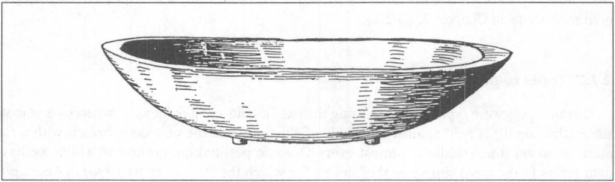

**Figure 5:** POc *tabiRa ‘wooden bowl’

This last set could be taken to reflect a POc **tabili, but their formal and semantic similarity to reflexes of *tabiRa suggests that this inference is not justified. Rather, they are probably descended from an etymon which originated somewhere in the Solomons in the borrowing of a reflex of *tabiRa denoting a trade item, apparently a wooden dish used for mashing and/or crushing.

A term with more restricted distribution and apparently denoting a subtype of *tabiRa is PNGOc *gabom ‘wooden dish’:

| **PNGOc** |  | *gabom | ‘wooden dish’ |
| --- | --- | --- | --- |
| NNG | Takia | *gab* | ‘cup made of half a coconut shell’ |
| NNG | Mapos Buang | *gabum* | ‘carved wooden dish or bowl’ |
| PT | Sewa Bay | *kaboma* | ‘wooden dish’ |
| PT | Wedau | *aboma* | ‘wooden dish’ |
| PT | Misima | *(ulun ab) gabom* | ‘simple unrestricted earthenware vessel found on Brooker Island’ |

PSS *popo ‘wooden bowl’ is reconstructable (Gela *popo* ‘a bowl’, ‘Are’are *hoho* ’a wooden bowl for pounding food’, Lau *fofo* ‘a round wooden dish’) but no cognates are known outside the Southeast Solomons.

| **PCP** |  | *kumete | ‘large wooden bowl’ (used as a mortar in pounding, mashing food and/or in stone-boiling) (Lichtenberk 1994) |
| --- | --- | --- | --- |
| Fij | Rotuman | *ʔumefe* | ‘bowl’ |
| Fij | Bauan | *kumete* | ‘wooden bowl’ |
| Pn | Tongan | *kumete* | ‘kava bowl’ |
| Pn | East Futunan | *kumete* | ‘wooden bowl, wooden trough’ |
| Pn | Kapingamarangi | *ŋumade* | ‘large wooden bowl for pounding food’ |
| Pn | Tahitian | *ʔumete* | ‘wooden trough or bowl (ovoid in shape)’ |

cf. also: the following probable loans from Polynesia:

| NCV | Mota | *wumeto* | ‘wooden bowl used for stone-boiling’ |
| --- | --- | --- | --- |
| Mic | Kiribati | *kumete* | ‘kind of wooden mortar trough; hollow, empty, concave; thin, ravenous (hungry)’ |

#### 2.2.2. Cup, liquid container

One of the most widely-used containers was the coconut-shell cup, for which we have several reconstructions. The term for a gourd also refers to a water bottle in some languages.

| **POc** |  | *(b,bʷ)ilo | ‘coconut shell used as liquid container’ |
| --- | --- | --- | --- |
| Adm | Lou | *pil* | ‘coconut shell used for soup’ |
| Adm | Titan | *pʷe-pʷil* | ‘coconut shell’ |
| Adm | Drehet | *pʷi-pʷiŋ* | ‘coconut shell’ |
| MM | Tolai | *bilo* | ‘cup’ |
| SES | Longgu | *bʷilo* | ‘coconut shell used as liquid container’ |
| SV | Lenakel | *(ui)pəl* | ‘container’ |
| SV | Anejom̃ | *ne-pec-* | ‘container’ |
| SV | Anejom̃ | *(inhu)pec* | ‘container’ |
| Fij | Wayan | *bilo* | ‘cup, drinking vessel, formerly a half-coconut’ |
| Fij | Bauan | *bilo* | ‘cup or dish, originally a half-coconut’ |

| **POc** |  | *lasa | ‘coconut half-shell cup’ |
| --- | --- | --- | --- |
| NNG | Tami | *lat* | ‘coconut shell’ |
| NNG | Bing | *lās* | ‘coconut half-shell cup’ |
| NNG | Numbami | *lasa* | ‘coconut half-shell cup’ |
| MM | Tolai | *lā* | ‘dish, bowl, any open utensil; shell of a coconut’ |
| MM | Selau | *las* | ‘young drinking coconut’ |
| NCV | Mota | *lasa* | ‘drinking cup’ |
| NCV | Mota | *(vin)lasa* | ‘cup *lasa* made of coconut shell *vin*’ |
| NCV | Raga | *laha* | ‘drinking cup made from coconut shell’ |
| NCV | Nguna | *lāsa* | ‘coconut half-shell cup’ |
| Mic | Marshallese | *lat* | ‘coconut shell; skull’ |

| **PEMP** |  | *ubi, *ibu | ‘drinking vessel’ (Blust 1978b) |
| --- | --- | --- | --- |
| **POc** |  | *ubi, *ibu | ‘half coconut shell used as a drinking cup’[^3] |
| NNG | Adzera | *umpi, impi* | ‘coconut-shell cup, spoon’ |
| SES | Ulawa | *ipu* | ‘hollow in tree holding water’ |
| Mic | Kiribati | *ipu* | ‘(coconut-shell) toddy container’ |
| Fij | Rotuman | *ipu* | ‘cup, drinking vessel’ |
| Pn | Tongan | *ipu* | ‘cup’ |
| Pn | Samoan | *ipu* | ‘(coconut-shell) cup; bowl; dish’ |
| Pn | Rapanui | *ipu* | ‘gourd, container for liquid’ |
| Pn | Rarotongan | *ipu* | ‘generic for articles that serve as basin, cup +, made in old days from coconut shell or calabash’ |

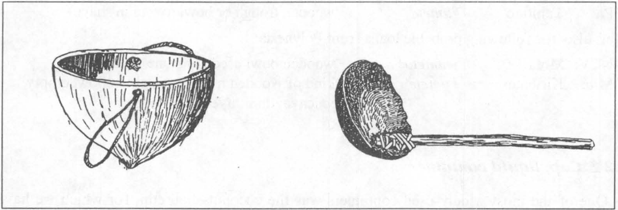

**Figure 6:** POc *(b,bʷ)ilo ‘coconut shell used as liquid container’, POc *lasa, POc *ubi/*ibu ‘coconut half shell-cup’ **Figure 7**: POc *kulopi ‘cup, ladle’ (from Nevermann_1934: 179)

| **PMP** |  | *ka(ŋ)bu(q) | ‘ladle, dipper’ (Blust 1972b) |
| --- | --- | --- | --- |
| **POc** |  | *kabu | ‘cup, ladle’ |
| Adm | Loniu | *kopu* | ‘bowl made by coiling slender bundles of natural fibre’ |
| Pn | Tongan | *kapu* | ‘form into a cup-like shape, esp. a banana leaf’ |
| Pn | Samoan | *ʔapu* | ‘cup made from leaf’ |
| Pn | Tuamotuan | *kapu* | ‘ladle’ |
| Pn | Hawaiian | *ʔapu* | ‘coconut-shell cup’ |

The gloss proposed for the following reconstruction is highly tentative:

| **POc** |  | *kulopi | ‘ladle, bailer’ |
| --- | --- | --- | --- |
| Adm | Loniu | *oloh* | ‘wooden bailer’ |
| MM | Vitu | *kolopi* | ‘basket’ |
| MM | Bola | *kulopi* | ‘basket’ |
| MM | Tolai | *kul-kulup* | ‘ladle, spoon’ |

An additional reconstruction, POc *asu (V) ‘scoop or ladle out’ ; (N) ‘ladle, bailer’, from PMP *aŋsu ‘scoop or bail out’ is included in Chapter 7, §7.4.

The following set, from Ross (1996a), is listed because explanation is needed for the fact that it is apparently reflected only in Yapese and NNG languages: is it a retention or a borrowing? (Takia *-ae-*, Bilibil, Megiar *-ai-* reflect *-a- which has undergone umlaut because of a lost final *-i.)

| **POc** |  | *d(r)ag(i) | ‘k.o. container’ (?) |
| --- | --- | --- | --- |
| Yap | Yapese | *ðāg* | ‘coconut-shell container’ |
| NNG | Takia | *daeg* | ‘dish’ |
| NNG | Bilibil | *daig* | ‘dish’ |
| NNG | Megiar | *daig* | ‘dish’ |
| NNG | Mapos Buang | *dɛg* | ‘cooking pot’ |
| NNG | Patep | *dɛg* | ‘cooking pot’ |

#### 2.2.3. Water bottle

Water may be carried and stored in bamboo or coconut-shell bottles stoppered with leaves. Blust has reconstructed a term for a coconut-shell bottle:

| **PSHWNG** |  | *waip | ‘water container’ (ACD) |
| --- | --- | --- | --- |
| **POc** |  | *wai(p) | ‘coconut shell water bottle’ |
| SES | Arosi | *wai* | ‘water container’ |
| Fij | Rotuman | *vai* | ‘cask’ |
| Pn | Samoan | *vai* | ‘coconut gourd’ |
| Pn | Rennellese | *bai* | ‘coconut-shell bottle’ |
| Pn | Anutan | *vai* | ‘water container’ |
| Pn | Māori | *wal* | ‘vessel to hold water + ; calabash’ |

but adds a warning note that the Oceanic forms cited may reflect POc *waiR ‘fresh water’. If so, all that can be inferred is a second gloss for this reconstructed form (ACD).

| **PROc** |  | *tapaya | ‘(gourd or coconut-shell) container, bottle’ |
| --- | --- | --- | --- |
| NCV | Mota | *(wo)tavae* | ‘kind of gourd, eaten’ (*wo-* ‘prefix indicating form, i.e. round object, fruit’) |
| NCV | Raga | *tavai* | ‘gourd’ |
| Fij | Bauan | *tavaya* | ‘bottle’ |
| Pn | Takuu | *tafā* | ‘flask made of coconut shell’ |
| Pn | Māori | *tahā* | ‘calabash with narrow mouth’ |

#### 2.2.4. Stopper

A number of terms are reconstructable for the plug, probably of rolled leaves, used to stop up the mouth of a water bottle:

| **POc** |  | *joŋ-a(n,ŋ) | ‘plug, bung, stopper’ |
| --- | --- | --- | --- |
| NNG | Manam | *ro-zoŋa* | [N] ‘plug’ |
| NNG | Adzera | *nzoŋan* | [V] ‘plug’ |
| SES | Gela | *do-doŋa-na* | ‘fitted tight as a cork’ |

This is a nominalisation of the verb below (cf. Ch. 2, §3.2.1):

| **PAn** |  | *seŋseŋ | ‘cork, stopper, plug’ (Blust 1986) |
| --- | --- | --- | --- |
| **POc** |  | *jojoŋ, *joŋi | ‘plug, stop, caulk’ |
| NNG | Gitua | *zozon* | [V] ‘plug, stop’ |
| NNG | Tami | *jojoŋ* | [N, V] ‘cork’ |
| NNG | Gedaged | *dod* | ‘cork, stopper made out of leaves rolled together to stop the hole in the coconut-shell water container’ |
| NNG | Numbami | *dodoŋa* | [V] ‘plug’ (epenthetic *-a*) |
| NNG | Yabem | *sòŋ* | [v] ‘plug’ |
| NNG | Manam | *rozoŋ* | ‘plug a hole in something, plug (bottle +)’ |
| NCV | Raga | *siŋo(hi)* | ‘stopper, cork’ (metathesis) |

Two other etyma are reconstructable in the domain ‘lid, cover, stopper’, but it is impossible to determine their exact meanings:

| **POc** |  | *buruŋ(a) | [N] ‘cover, plug’ (?) |
| --- | --- | --- | --- |
| Adm | Drehet | *(na)puluŋ* | ‘plug, usually for a teapot spout’ |
| MM | Patpatar | *buruŋ* | [N] ‘cover’ |
| MM | Ramoaaina | *buru-buruŋ* | [N] ‘cover’ |

| **PEOc** |  | *bʷalu | ‘cover, lid, stopper’ |
| --- | --- | --- | --- |
| SES | Arosi | *bʷaru* | ‘put lid on, stopper in bamboo water vessel’ |
| SES | Arosi | *bʷaru-na* | ‘lid, plug, stopper’ |
| Mic | Carolinian | *bʷala-bʷal* | ‘cover, lid, top for s.t.; be covered’ |
| Mic | Carolinian | *bʷalí* | ‘cover s.t.’ |

#### 2.2.5. Lime pot

There is one other kind of container associated with Melanesians other than the inhabitants of Vanuatu and Fiji, and that is the lime pot of betel-nut users. The lime container is usually a gourd, coconut shell or small tightly-woven basket. A lime spatula of bone or wood, sometimes highly decorated, rests in the gourd and is used to convey lime to the mouth. We have a reconstruction for the spatula, POc *d(r)amu, but no specific term for the lime pot. In a number of word lists the term for lime (often from POc *qapu(R)) also can refer to the pot. We have reconstructed a PROc term for a gourd, *tapaya ‘gourd, water bottle’, as there are no cognates from SES, which is the only area of eastern Oceanic where betel is chewed, and we lack any Western Oceanic reconstruction.

#### 2.2.6. Lime spatula

| **POc** |  | *d(r)amut | ‘lime spatula’ |
| --- | --- | --- | --- |
| Adm | Mussau | *(ai) ra-ramuti* | (*ai* ‘stick’) |
| Adm | Lou | *rem* | ‘lime spatula’ |
| NNG | Gedaged | *dam* | ‘(bone or wood) lime spatula’ |
| MM | Nakanai | *damu* | ‘lime spatula’ |
| SES | Sa’a | *demu* | ‘chew betel nut’ |
| SES | Arosi | *damu* | ‘chew betel nut’ |

The final *-i* of Mussau *ra-ramuti* suggests that this reflects a transitive verb *d(r)amut-i-, perhaps ‘add lime to a chew of betel nut’.

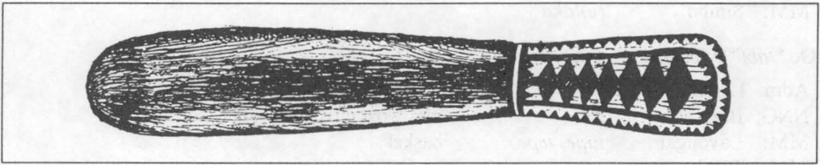

**Figure 8:** POc *d(r)amut ‘lime spatula’

### 2.3. Woven containers

Usable baskets or trays can be improvised in a few minutes from the wealth of leaves and fibres generally within easy reach. Baskets used today vary greatly in size, shape and function. They range from the large trays used at feasts to tiny purses carried within string bags. Individual communities have evolved their own shapes, styles and traditions of use. Some styles may be so individual or striking that they come to be representative of a particular region or community. Baskets may be with or without handles; carried over the shoulder, from the head or hand or under the arm; used by men only or women only; strictly utilitarian or finely decorated, multi-purpose or highly specific in their use. Different styles may be distinguished by name.

Perhaps surprisingly, in view of the widespread use of bags and baskets and the large number of terms collected, it has proved difficult to locate clear cognate sets with broad distribution. Any proliferation of types and styles would require new terms or reinterpretation of old terms. The likelihood of borrowing is also high.

| **PMP** |  | *ka(n)tuŋ | ‘basket, pocket in clothing’ (Dempwolff 1938) |
| --- | --- | --- | --- |
| **POc** |  | *katu(m,ŋ) | ‘basket’ |
| SES | Arosi | *kaso* | ‘basket without a handle’ |
| NCV | Lonwolwol | *aro(bol)* | ‘basket, container; sack, bag’ (*-bol* from PROc *bola ‘coconut leaves woven together’) |
| NCV | Paamese | *atu(voi)* | ‘basket of coconut leaves’ |
| SV | Lenakel | *karəm* | ‘basket’ |
| SV | Anejom̃ | *in-ɣat* | ‘pandanus, basket’ |
| Mic | Woleaian | *xato* | ‘kind of small basket for food’ |
| Mic | Carolinian | *xɔ̄t* | ‘k. o. basket’ |
| Fij | Bauan | *kato* | ‘basket, box, trunk, suitcase’ |
| Pn | Tongan | *kato* | ‘basket; suitcase; pouch; pocket’ |
| Pn | West Futunan | *kato* | ‘basket with a four-cornered base’ |

Arosi *-s-* from *-t- is conditioned by a following *-u, supporting its reconstruction rather than that of *-o. Carolinian *xɔ̄t* and some other Micronesian cognates are problematic, since their *-t* reflects POc *s or *j rather than *t.

| **POc** |  | *laka | ‘basket’ |
| --- | --- | --- | --- |
| Adm | Mussau | *laka* | ‘basket’ |
| MM | Nalik | *laka* | ‘basket’ |
| MM | Tabar | *rake* | ‘netbag; basket’ |
| MM | Simbo | *(e)laka* | ‘basket’ |

| **POc** |  | *ta(b,bʷ)e | ‘basket, probably small’ |
| --- | --- | --- | --- |
| Adm | Loniu | *tapʷa* | ‘basket, string bag’ |
| NNG | Bing | *tāb* | ‘mat woven from coconut fronds’ |
| MM | Lavongai | *tape, tepe* | ‘basket’ |
| MM | Tigak | *tape* | ‘basket’ |
| MM | Sursurunga | *təp* | ‘basket type’ |
| MM | Patpatar | *tep* | ‘basket for carrying food’ |
| Mic | Marshallese | *cepe* | ‘small basket’ |
| Fij | Wayan | *tabe* | ‘small oval basket, usually woven from coconut or pandanus leaves’ |
| Fij | Bauan | *(i)tabe* | ‘small oval basket without handles’ (*i-* < POc *i- INS) |
| Pn | Tongan | *tape* | ‘k.o. shallow basket’ |

| **PWOc** |  | *kase | ‘k.o. basket’ |
| --- | --- | --- | --- |
| PT | Gapapaiwa | *kase-kase* | ‘basket of coconut fronds’ |
| PT | Misima | *ke-kehe* | ‘basket of coconut fronds used as a handbag’ |
| PT | Sudest | *kaði-kaðiye* | ‘(name of a) basket’ |
| MM | Barok | *kis* | ‘netbag; basket’ |
| MM | Lamasong | *kis* | ‘basket’ |
| MM | Sursurunga | *kas* | ‘basket type, closely woven like a Buka basket’ |
| MM | Patpatar | *kas* | ‘basket’ |

cf. also:

| Adm | Mussau | *keru* | ‘k.o. basket’ |
| --- | --- | --- | --- |

| **PROc** |  | *kete | ‘belly, basket’ (Biggs 1965) |
| --- | --- | --- | --- |
| NCV | Mota | *gete* | ‘woven basket’ |
| NCV | Raga | *gete* | ‘basket made of plaited coconut leaves’ |
| Fij | Bauan | *kete* | ‘belly, stomach’ |
| Fij | Bauan | *kete-kete* | ‘basket’ |
| Pn | Tongan | *kete* | ‘stomach, abdomen’ |
| Pn | Samoan | *ʔete* | ‘bag, basket’ |
| Pn | Māori | *kete* | ‘plaited flax basket with carrying handles’ |

This form is unlikely to be of POc ancestry, as medial *-e- is rare in POc. It may well have an association with one of the two *k-initial forms above.

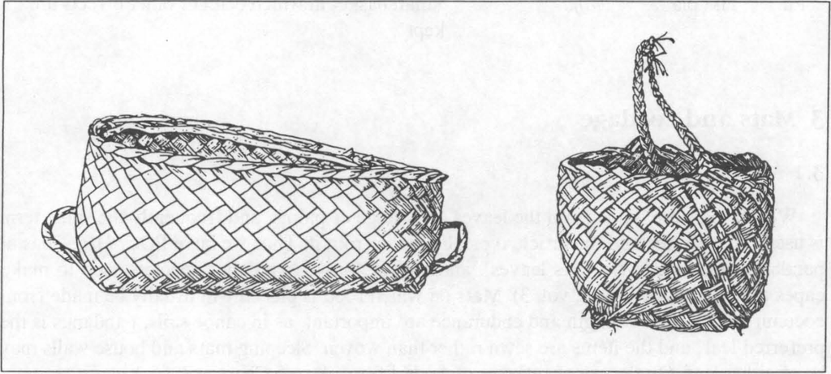

**Figure 9:** Reconstructions (non-specific) include: POc *katu(m,ŋ) ‘basket’, POc *laka ‘basket’, POc *tab(w)e ‘basket, probably small’, POc *taŋa ‘basket or bag, small, used for personal effects’ (after Koch_1986: 104 and n.d.:59)

Biggs (1993) lists two further terms for PPn, *taapola ‘basket plaited from a single coconut frond’ (from PROc *bola ‘coconut leaves woven together for any purpose’. See under §3.1 Mats); and *qora ‘fishing basket’.

Bags, typically of twine made from fibres rolled together on the thigh and then knotted into a mesh, are more likely to be used for carrying than for storage. They are a prominent item among western Oceanic peoples, the women carrying them slung from a band round the head, and the men generally over one shoulder. On the New Guinea mainland, they are the means by which a woman carries a baby. The widespread modern term for these bags is *bilum*, a Tok Pis in term apparently from Tolai, but without cognates outside MM. The present distribution pattern of use would seem to reflect a possible Papuan origin for the net bag. In east New Britain (Tolai and Baining at least) heavy loads are carried in a coconut leaf basket suspended from the forehead by a tumpline (Ann Chowning, pers.comm.). The following reconstruction may have been a general term for a small plaited or woven container which has come to refer to a net bag in parts of western Oceania.

| **POc** |  | *taŋa | ‘basket or bag, small, used for personal effects’ |
| --- | --- | --- | --- |
| NNG | Lukep | *taŋa* | ‘net bag, womb’ |
| NNG | Gedaged | *taŋ* | ‘net bag used by women’ |
| PT | Kilivila | *(va)taga* | ‘small basket (very simply plaited)’ |
| PT | Dobu | *tana* | ‘dilly bag’ (Grant) |
| MM | Meramera | *taŋa* | ‘netbag; nest; web; basket’ |
| MM | Tangga | *taŋ* | ‘netbag, basket’ |
| SES | Arosi | *aŋa(na)* | ‘plaited bag with string handles, generic’ |
| NCV | Raga | *taŋa* | ‘small basket made of plaited pandanus leaves’ |
| NCV | Ambae | *taŋa* | ‘small basket, woven from pandanus, used like a handbag for small personal items’ |
| Fij | Bauan | *taŋa* | ‘bag, pocket, sack’ |
| Pn | Tongan | *taŋa(i)* | ‘bag, sack’ |
| Pn | Tikopia | *taŋa* | ‘small basket in which betel or other effects are kept’ |

## 3. Mats and cordage

### 3.1. Mats

Woven mats are made from the leaves of a range of palms, and frequently the same term is used for both tree and the article typically made from it. Thus we have POc *kiRe ‘coastal pandanus: mat made from its leaves’, and PWOc *moke ‘pandanus species, used to make capes and mats’ (see Plants, vol. 3). Mats on which food is placed will usually be made from coconut leaf. Where strength and endurance are important, as in canoe sails, pandanus is the preferred leaf, and the items are sewn rather than woven. Sleeping mats and house walls may be of either leaf. On the use of reflexes of *qebal for sails, see Chapter 7, §5.1.

| **POc** |  | *qebal | ‘pandanus mat, possibly sleeping mat’ |
| --- | --- | --- | --- |
| NNG | Numbami | *embala* | ‘mat’ |
| PT | Molima | *ʔebana* | ‘sewn pandanus mat; pandanus used for it’ |
| PT | Sinaugoro | *ɣeba* | ‘pandanus mat, possibly sleeping mat’ |
| SES | Longgu | *eba* | ‘pandanus mat, possibly sleeping mat’ |
| SES | Lau | *eba* | ‘mat of pandanus; a sail’ |
| SES | Kwaio | *eba* | ‘sleeping mat’ |
| NCV | Mota | *epa* | ‘mat, piece of matting; sail of matting’ |
| NCV | Raga | *ebe* | ‘sleeping-mat’ |
| SV | Anejom̃ | *n-ep* | ‘pandanus mat for carrying a child’ |
| Mic | Carolinian | *āp* | ‘small soft mat used for babies’ |
| Mic | Woleaian | *yepe* | ‘baby’s mat’ |
| Pn | Tongan | *ʔepa* | ‘mats (collectively) given to a bride’ |
| Pn | Samoan | *epa* | ‘native mats and cloth on which dead chief is laid’ |
| Pn | Tikopia | *epa* | ‘ritual offering of finely plaited pandanus mats’ |

| **POc** |  | *tabakau | ‘mat woven from coconut leaves’ |
| --- | --- | --- | --- |
| NNG | Lukep | *pakau* | ‘trash mat: a woven coconut-leaf mat used to carry trash and sand’ |
| NCV | Mota | *tapaŋau* | ‘mat of coconut leaves, large, coarsely woven’ |
| SV | Anejom̃ | *(nicip)akau* | ‘chief’s single thickness coconut mat with large spine’ |
| Fij | Wayan | *tabakau* | ‘coarsely woven mat of coconut leaves’ |
| Pn | Tongan | *tapakau* | ‘large coconut leaf suitable for making floormats’ |
| Pn | Samoan | *tapaʔau* | ‘coconut leaf floormat’ |
| Pn | Māori | *takapau* | ‘floormat; plaited floormat’ (metathesis) |

| **PROc** |  | *bola | ‘coconut leaves woven together for any purpose, including mats, baskets, thatch’ |
| --- | --- | --- | --- |
| NCV | Nguna | *pora* | ‘woven wall panel’ |
| NCV | Lonwolwol | *(aro)bol* | ‘basket, container; sack, bag’ (*aro* > POc *kato ‘basket’) |
| Fij | Rotuman | *pora* | ‘coconut leaf used for walls +’ |
| Fij | Wayan | *bola* | ‘basket, especially four-cornered type with lid’ |
| Fij | Bauan | *bola* | ‘leaf of coconut plaited into a sort of narrow mat for thatching’ |
| Pn | Tongan | *pola* | ‘plaited coconut leaves used for making walls or roof, or as a food tray; fishing net made of plaited coconut leaves, and used in community fishing’ |
| Pn | Samoan | *pola* | ‘plaited coconut leaf wall screen’ |
| Pn | Māori | *pora* | ‘coarse cloak; floormat’ |
| Pn | Tikopia | *pora* | ‘small plaited coconut leaf mat’ |

It is possible that the two NCV reflexes in the above set are borrowings from Polynesia (Ross Clark pers.comm.). If so, this reduces the reconstruction from PROc to PCP.

| **PEOc** |  | *ibe | ‘mat’ (Pawley 1976) |
| --- | --- | --- | --- |
| SES | Gela | *ibe* | ‘mat’ |
| SES | ’Are’are | *ipe* | ‘mat, bed’ |
| Fij | Bauan | *ibe* | ‘mat’ |

Two further terms have been reconstructed for PPn only: *fala ‘plaited pandanus mat’, and *fāliki ‘cover floor with mats or grass; floor covering’, both from Biggs (1993).

#### 3.1.1. Weaving, plaiting

The distinction between weaving and plaiting is not clear even in English, although as a broad principle, weaving produces a fabric and plaiting a braid. Sometimes plaiting is used in descriptive accounts as a general term for all forms of mat and basket making. There are some processes in mat making where the edges of the mat are finished with a kind of braiding. Any distinction between the terms in word lists is consequently not considered significant, unless clarified by context. Where plaiting is used in reconstructions here, it is to be taken as an inclusive term for all kinds of mat and basket manufacture (but excluding loom weaving).

| **PMP** |  | *batuR | ‘plait, weave (mats, baskets +)’ (ACD) |
| --- | --- | --- | --- |
| **POc** |  | *patu(R), *patuR-i- | ‘tie, plait, weave (mats, baskets +)’ |
| Adm | Mussau | *atu* | ‘plait (mats, baskets)’ |
| NNG | Lukep | *-watu* | ‘tie a pig up preparatory to slaughter’ |
| PT | Kilivila | *vatunu* | ‘rope, line’ (borrowed from elsewhere in PT) |
| PT | Motu | *hatu-* | ‘plait (mats +), weave; twist a small rope’ |
| MM | Banoni | *pacu* | ‘tie’ |
| SES | Tolo | *vatuli-* | ‘weave (s.t.)’ |
| SES | Lau | *faoli* | ‘weave (s.t.)’ |
| SES | Arosi | *hauri-* | ‘plait (s.t.)’ |
| NCV | Tamambo | *vatu* | ‘weave, plait’ |
| NCV | Ambae | *vatu* | ‘weave’ |
| Fij | Wayan | *vatu* | ‘be formed or built in a certain way’ |
| Pn | Tongan | *fatu* | [V] ‘fold; begin the making of a mat; construct the framework of a house’ |
| Pn | Samoan | *fatu* | ‘assemble (s.t.) with the hands’ |
| Pn | Hawaiian | *haku* | ‘compose, put in order, arrange; weave (flower necklace +)’ |

| **PMP** |  | *añam | ‘plait (mats, baskets +)’ (Blust 1980b) |
| --- | --- | --- | --- |
| **POc** |  | *aña | ‘woven, braided’ |
| Mic | Kiribati | *ana* | ‘term used in mat weaving to designate a certain width’ |
| Fij | Bauan | *yana-yana* | ‘(mats +) loosely plaited or woven’ |
| Pn | Tahitian | *ana(ve)* | ‘twisted cord made from small combings of coconut fibre’ (Oliver 1974: 140) |

| **POc** |  | *paus, *paus-i- | ‘weave, plait’ |
| --- | --- | --- | --- |
| NNG | Tami | *wa-wau* | ‘weave’ |
| NNG | Kilenge | *pau-* | ‘weave’ |
| SES | Gela | *vauhi-* | ‘weave, plait’ |
| SES | ’Are’are | *haosi-* | ‘weave, plait’ |
| SES | Longgu | *vaosi-* | ‘weave (s.t.)’ |
| NCV | Mota | *vau* | [v] ‘mat, plait, weave (mats, baskets)’ |
| NCV | Nguna | *vausi-* | ‘weave’ |
| SV | Anejom̃ | *(a)hod* | ‘weave’ |
| SV | Southwest Tanna | *kwuh* | ‘weave’ |

| **POc** |  | *tiki | [V] ‘plait (mat +)’ (ACD) |
| --- | --- | --- | --- |
| Adm | Lou | *tik* | [v] ‘plait (mats, baskets)’ |
| Adm | Loniu | *tiʔi* | ‘weave’ |
| NCV | Mota | *tig* | ‘finish off the plaiting of a mat’ |

| **POc** |  | *pai | ‘weave’ |
| --- | --- | --- | --- |
| NNG | Tuam | *va-vai* | ‘weave’ |
| NNG | Gitua | *va-vai* | ‘weave’ |
| NNG | Numbami | *wa-wai* | ‘weave’ |
| NNG | Kove | *wal* | ‘make a basket, plait a door’ |
| NNG | Kove | *wa-waiŋa* | ‘string figures’ |
| PT | Misima | *vei* | ‘plait’ |
| MM | Vitu | *vai* | ‘weave’ |
| MM | Lavongai | *pai* | ‘weave’ |
| MM | Label | *hai* | ‘weave’ |
| NCV | Paamese | *hai* | [VT] ‘weave, make fence’ |

Biggs (1993) adds one lower-level reconstruction: PPn *laŋa ’plait (mat, basket) .

Ann Chowning (pers.comm.) has offered an additional sense to POc *raraŋ, *raraŋ-i- (from PAn *da(n)daŋ), which Lichtenberk glosses as ‘warm oneself by fire’; ‘warm up, reheat (esp. food)’ (see Chapter 6, §3.5, for the full cognate set). She contributes cognates from Molima, Kove and Nakanai which all refer to the preparation of pandanus leaves for mat making by softening them over a fire, and accord closely with the gloss of the single Polynesian cognate.

| **POc** |  | *raraŋ, *raraŋ-i- | ‘heat s.t. or warm oneself by fire’ |
| --- | --- | --- | --- |
| NNG | Kove | *lala* | ‘wilt pandanus leaves over a fire in order to soften them for mat making’ |
| PT | Molima | *lala* | ‘wilt pandanus leaves over a fire in order to soften them for mat making’ |
| MM | Nakanai | *lala* | ‘wilt pandanus leaves over a fire in order to soften them for mat making; hold over the fire, heat over the fire (as bamboo which is to be bent)’ |
| Pn | Pukapukan | *lala* | ‘bleach pandanus leaves by passing them over a fire’ |

### 3.2. Cord, twine

The simplest material for tying would have been lengths of vine or rattan, or strips of suitable bark, such as hibiscus. (POc *waRoc ‘vine, creeper, rope, string’; POc *quwe ‘rattan’ (see Plants, vol. 3)). A strong light twine could be made by rolling fibres together on the thigh. The strongest cords and ropes are made by twisting or plaiting various kinds of fibres or rolled thread, principally coconut fibre or hibiscus bark.

| **POc** |  | *loqi | ‘make thread by rolling fibres on the thigh’ (Chowning 1991: *loi ‘thread made …’) |
| --- | --- | --- | --- |
| NNG | Kove | *loi* | ‘make thread by rolling fibres on the thigh’ |
| MM | Nakanai | *loi* | ‘rub between the hands’ |
| MM | Tolai | *loe* | [V] ‘twist, coil’ |
| MM | Tolai | *lo-loi* | [v] ‘roll or coil (strips of shell money)’ |
| SES | Kwaio | *loi* | ‘weave a net, knit’ |
| NCV | Nguna | *lo-lo* | ‘thread’ |
| Pn | Māori | *roi(roki)* | ‘secured, tied up; knot, bind’ |

An unrelated PPn term has been reconstructed for the same process, *amo ‘prepare fibres for string making (by rubbing between hands or on thigh); prepared fibre’ (Biggs & Clark 1993).

| **POc** |  | *tali | ‘rope, cord, plaiting’ |
| --- | --- | --- | --- |
| Adm | Lou | *tel* | ‘rope, string’ |
| SES | Gela | *tali* | ‘rope’ |
| SES | Arosi | *ari* | [N] ‘rope’; [v] ‘plait’ |
| SES | Arosi | *ari(heda)* | ‘flat-shaped rope’ |
| SES | Arosi | *ari(hua)* | ‘rounded rope’ |
| SES | Arosi | *ari(huemadi)* | ‘knotted line’ |
| NCV | Mota | *tal, tali* | ‘rope, cord, made of plaited or twisted lines’ |
| Fij | Wayan | *tali* | [v] ‘plait, weave; rope’ |
| Fij | Bauan | *tali* | [v] ‘plait, interweave’ |
| Pn | Anutan | *tari* | ‘kind of plaiting’ |
| Pn | Māori | *tari* | ‘plaiting as opposed to weaving or twining’ |

| **PMP** |  | *piri(c,t) | ‘twist, plait’ (Blust 1970) |
| --- | --- | --- | --- |
| **POc** |  | *piri | ‘plait a cord, twist, wrap around’ |
| Adm | Mussau | *iri* | ‘tie, bind by wrapping around’ |
| NNG | Gedaged | *piȴi* | ‘weave (mats, sails +), (V) braid, knot (the strands of grass-skirts)’ |
| PT | Kilivila | *vili* | ‘tum; make grass-skirts; be twisted’ |
| PT | Molima | *vili* | ‘make a skirt, roll a cigarette, put a headdress round the head’ |
| PT | Motu | *hiri* | ‘fasten by twisting round and round; tie up (a parcel, bundle), twisting string all round it; kill (pig) for visitors’ |
| MM | Tolai | *pir* | ‘plait (basket, mat +)’ |
| MM | Nakanai | *viri* | ‘twist, wind up, wind around’ |
| MM | Simbo | *viri* | ‘plait, make a basket’ |
| SES | Sa’a | *hiri* | [v] ‘lap with string, bind spears or arrows’ |
| SES | Arosi | *hiri* | ‘twist, twine round, (snake) coil, wind (a line) round’ |
| NCV | Mota | *vir* | ‘twist, wring, squeeze with a twist, plait’ |
| NCV | Tamambo | *viri* | ‘twist, plait, braid; coconut milk’ |
| SV | Sye | *(e)vi* | ‘weave (basket)’ |
| NCal | Nemi | *fili* | ‘braid’ |
| Mic | Ponapean | *pir* | ‘tum, spin, twist’ |
| Mic | Kosraean | *pɨr(aki)* | [V] ‘braid, plait’ |
| Fij | Rotuman | *hiri* | ‘plait three strands of sennit, hair +, and the “tail” of a basket or floormat made of coconut-leaf, this tail itself being called a *hiri*’ |
| Fij | Bauan | *viri* | ‘lash (fence, raft +)’ |
| Pn | Samoan | *fili* | ‘plait, braid (sennit, hair +)’ |

cf. also:

| PT | Gumawana | *(ki)pili* | ‘twist s.t., unscrew a lid’ |
| --- | --- | --- | --- |
| MM | Tolai | *pir* | ‘plait (basket, mat +)’ |

| **PEOc** |  | *piri-piri | ‘twine round and round; thing made by braiding’[^4] |
| --- | --- | --- | --- |
| SES | Sa’a | *hiri-hiri* | ‘plaited spear’ |
| SES | Arosi | *hiri-hiri* | ‘twist, twine round, (snake) coil, wind a line round; a thread for tying a hook to a line’ |
| Mic | Woleaian | *piri-pir* | ‘tie, twist, fold, lash (as in twisting ropes)’ |
| Pn | Samoan | *fili-fili* | ‘chain’ |
| Pn | Hawaiian | *hili-hili* | [v] ‘braid, plait, string’ |

Reduplication was regularly used to form intransitive verbs from verbs which were otherwise transitive (see Ch. 2, §3.1.2).

| **PEOc** |  | *pilos, *pilos-i- | ‘make a cord by twisting fibres on the thigh’ (Bethwyn Evans pers.comm.) |
| --- | --- | --- | --- |
| SES | Lau | *filo, filosi-* | ‘twist together (strands), twist round’ |
| SES | Kwaio | *filosi-* | ‘twist, wring’ |
| SES | ’Are’are | *hirosi-* | ‘wring, twist, roll’ |
| SES | Arosi | *hiro, hirosi-* | ‘revolve, spin’ |
| NCV | Port Sandwich | *vlösi-* | ‘roll on one’s thigh’ |
| NCV | Paamese | *vilesi-* | [VT] ‘turn around, turn over’ |
| Fij | Bauan | *vulo* | ‘twist a thread on the knee’ |
| Pn | Tongan | *filo, filohi-* | ‘thread; spin, make thread, string, rope’ |
| Pn | Takuu | *filo* | ‘roll rope on thigh’ |
| Pn | Mangarevan | *hiro* | ‘make threads by rolling filaments on the thigh’ |
| Pn | Hawaiian | *hilo* | ‘twist, braid, spin; twisted, braided’ |

See Ch. 9 §§7-8, for discussion of the item above.

| **PWOc** |  | *mʷali | ‘braid large ropes (for use with canoes +)’ (Chowning 1991) |
| --- | --- | --- | --- |
| NNG | Lukep | *mol-* | ‘twist into a loop’ |
| NNG | Manam | *moli* | ‘plait’ |
| PT | Sudest | *mʷana(basi)* | ‘twist (s.t.)’ |
| MM | Nakanai | *mali* | ‘plait (mat)’ |

| **PMP** |  | *kapat | ‘cotton, thread’ (Dempwolff 1938) |
| --- | --- | --- | --- |
| **POc** |  | *kapa | ‘sennit’ |
| Fij | Wayan | *kava* | ‘(sennit) be rolled into a coil; a coil of sennit’ |
| Fij | Bauan | *kavā, kapā* | ‘roll of sinnet’ |
| Pn | Tongan | *kafa* | ‘sennit (string or rope made of coconut fibre)’ |
| Pn | Tikopia | *kafa* | ‘sennit cord plaited from fibre of coconut husk’ |
| Pn | Marquesan | *kaha* | ‘sennit rope used in lashing canoe’ |

The product of tying a piece of cordage is, of course, a knot. POc seems to have had no term dedicated to a knot as understood in English, but had the more generalised term *buku, which referred to a node, protuberance, joint or knot (this word was also used with the meaning ‘tie a knot’; see Chapter 9, § 10):

| **PMP** |  | *buku | ‘node (as in bamboo or sugarcane); joint; knuckle; knot in wood, string or rope’ (ACD; Dempwolff 1938) |
| --- | --- | --- | --- |
| **POc** |  | *buku | ‘node (as in bamboo or sugarcane); joint; knuckle; knot in wood, string or rope’ (ACD) |
| NNG | Manam | *buku* | ‘mountain; knuckle’ |
| NNG | Gedaged | *buku-n* | ‘knot on the stem of a tree, or a knot tied in a cord; knob; tumor, haemorrhoids’ |
| MM | Nakanai | *bu-buku* | ‘knot in a tree’ |
| MM | West Kara | *buki-* | ‘knee’ |
| MM | Tabar | *puk-puku* | ‘knee’ |
| MM | Tabar | *puku-* | ‘boil, ulcer’ |
| MM | Tolai | *buk* | ‘boil, ulcer, abscess; hence any lump, corner, point, knob +’ |
| MM | Tolai | *buku-* | ‘knee’ |
| MM | Babatana | *pu-puku* | ‘elbow’ |
| MM | Roviana | *puku-na* | ‘a knot’ |
| MM | Maringe | *pʰu-puku* | ‘knee, elbow’ |
| SES | Bugotu | *puku* | ‘a swelling from a blow; lump, knot, tumor’ |
| SES | Gela | *puku* | ‘a knot’ |
| SES | Gela | *vari-puku* | ‘tie a knot’ |
| Mic | Kiribati | *buki-ni-bai* | ‘elbow’ |
| Mic | Kiribati | *buki-narora* | ‘reef jutting out at end of land’ |
| Mic | Kosraean | *fuku-ne* | ‘ankle’ |
| Mic | Kosraean | *puku-n ne* | ‘shank, shin’ |
| Mic | Chuukese | *pʷ-pʷuk* | ‘knot’ |
| Fij | Bauan | *buku* | ‘the raised end of a shell + ; knot, protuberance’ |
| Fij | Bauan | *(i)buku* | ‘a knot’ |
| Fij | Bauan | *buku ni kai* | ‘hinge of a bivalve’ |
| Pn | Rennellese | *puku* | ‘knot, as in a tree’ |
| Pn | Māori | *puku* | ‘swelling, tumor, knob; head of seed, cob of corn; swell’ |

#### 3.2.1. Sewing

POc *saqi(t) was the term used specifically for sewing activities. The terms *(su)suk-i ‘pierce, sew (mats)’ and *(su)suRi ‘bone (needle); sew’ were also used for sewing, but this was not their primary meaning.

| **POc** |  | *saqi(t) | ‘sew’ (Milke 1961) ; ‘sew (pandanus mats, thatch +)’ (Chowning 1991) |
| --- | --- | --- | --- |
| Adm | Mussau | *saki* | ‘sew’ |
| Adm | Mussau | *saiki* | ‘sew (clothes)’ (cf. *sui*, *sufi* ‘sew (mats, thatch)’) |
| NNG | Amara | *sai-sai* | ‘sew’ |
| NNG | Kairiru | *sai* | ‘sew’ |
| PT | Motu | *dai(āhu)* | ‘close a bag by sewing up the mouth’ (*ahu* ‘closed’) |
| MM | Meramera | *sai* | ‘sew’ |
| MM | Nakanai | *sahi* | ‘sew’ |
| MM | Nakanai | *sa-sahi* | ‘sew two things together’ |
| SES | Lau | *tai* | ‘sew’ |
| SES | Arosi | *taʔi* | ‘sew, join together’ |

cf. also:

| NNG | Sengseng | *sihit* | ‘sew areca palm spathe pouches for lime; barricade a doorway by interlacing vines across’ |
| --- | --- | --- | --- |

| **PMP** |  | *cukcuk, *suksuk | ‘skewer’ (ACD) |
| --- | --- | --- | --- |
| **POc** |  | *(su)su(k) | ‘anything used to pierce, prick’ (cf. Ch. 9, §4.1) |
| NNG | Gitua | *zuzu* | ‘sharpened stick used like cooking fork’ |
| PT | Motu | *dudu* | ‘prod with a stick’ |
| MM | Nakanai | *susu(tola)* | ‘pierce the footprint (kind of sorcery)’ |
| SES | Gela | *susu(ihu)* | ‘hole in septum in nose; nose stick; strengthening sticks through thatch of house ridge’ (*ihu* ‘nose’) |
| SES | Lau | *susu* | [V] ‘point, prick, impale, pierce, poke out with a stick, sting, darn’ |
| NCV | Mota | *sus* | ‘pierce, run through’ |
| Fij | Rotuman | *susu* | ‘sew, prick’ |

In the following set there may be some blending of meaning between two formally close terms, POc *s(u,i)ri ‘pierce, poke’ (Ch. 9, §4.1) and POc *suRi ‘bone’, because needles were at times made from bones (of bird or flying fox or occasionally pig).

| **POc** |  | *(su)suRi | ‘bone (needle); sew’ (cf. POc *suRi ‘bone’) |
| --- | --- | --- | --- |
| Adm | Mussau | *sui* | ‘sew (mats), thatch’ |
| MM | Roviana | *susuri(na)* | ‘bone’ |
| SES | Sa’a | *suli(teru)* | ‘bone needle’ (*suli* ‘bone’) |
| SES | Arosi | *suri(ao)* | ‘needle for sewing thatch’ (*suri-suri* ‘bone’, *ao* ‘sago palm’) |
| NCV | Mota | *su-sur* | ‘sew, prick’ |

The following term for needle, POc *saRum, evidently had specific reference to a tattooing needle, in addition to a more general meaning.

| **PMP** |  | *zaRum | ‘needle’ (Dempwolff 1938) |
| --- | --- | --- | --- |
| **POc** |  | *saRum | ‘needle, tattooing needle’ (typically made from wing-bone of flying fox) |
| Adm | Mussau | *raum* | ‘needle’ |
| Adm | Lou | *sou-* | ‘needle’ |
| NNG | Lukep | *sar* | ‘needle (traditionally made of bat bone or fish bone)’ |
| MM | Nakanai | *salu* | ‘needle or awl’ |
| SES | Arosi | *taru* | ‘bat’s bone for tattooing’ |
| SES | ’Are’are | *taru(a)* | ‘needle, the bones of a flying fox’ |
| Fij | Bauan | *sau* | [v] ‘prick, as in tattooing’ |
| Fij | Bauan | *(i)sau* | ‘needle’ (*i-* < POc *i- INS) |
| Pn | Tongan | *hau* | ‘thin dagger, like a giant needle, used in spearing bonito’ |
| Pn | Samoan | *au* | ‘needle, tattooing comb’ |
| Pn | Tokelauan | *au* | ‘needle for sewing thatch; tattooing comb’ |

## 4. Tools

### 4.1. Cutting implements

#### 4.1.1. Axe, adze

Oliver (1989:88) identifies axe heads as having cutting ends bevelled on both sides, adzes as having cutting ends bevelled on one side only, and axe-adzes which are bevelled so as to be used either way. They are, of course, hafted differently on to their handle, the axe head lying along the same plane while the adze head is set at right angles to the handle. Axes would have been used primarily in tree-felling; adzes for such activities as the hollowing out and shaping of canoes, or the extraction of pith from sago palms. Either implement could have been utilised in the shaping of timber for the construction of houses, fenceposts etc. Although the preferred material for an adze blade was presumably basalt, archaeological sites in Island Oceania contain numbers of axes and particularly adzes, made of shell, mostly of *Tridacna*, the giant clam (Oliver 1989: 89). On coral atolls, shell often has by necessity to substitute for stone.

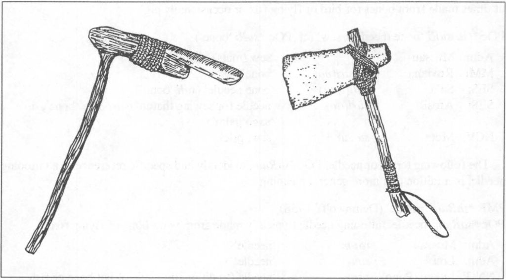

**Figure 10:** POc *kiRam ‘stone adze, axe’, POc *matau ‘axe’, POc *taku, POc *taRa(q) ‘adze’

| **PMP** |  | *kiRam | ‘axe or adze’ (ACD) |
| --- | --- | --- | --- |
| **POc** |  | *kiRam | ‘stone adze, axe’ (Milke 1968) |
| Adm | Mussau | *iema* | ‘knife’ |
| NNG | Manam | *kira* | ‘stone axe, axe blade’ |
| PT | Gumawana | *kiyama* | ‘axe’ |
| PT | Molima | *ilama* | ‘stone axe’ |
| PT | Motu | *ira* | ‘hatchet; adze’ |
| PT | Dobu | *ila* | ‘stone axe’ |
| MM | Vitu | *kira* | ‘axe’ |
| MM | Label | *iram* | ‘axe’ |
| MM | Tolai | *riam* | ‘the original stone (basalt) tomahawk’ (metathesis) |
| SES | Gela | *gila* | ‘stone adze, axe’ |
| SES | Kwaio | *ʔila* | ‘flint, flint tool’ |
| SES | Arosi | *ʔira* | ‘stone adze, axe’ |
| NCV | South Efate | *karam* | ‘axe’ |
| SV | Lenakel | *(ka)kil* | ‘sharpened stick (used as adze, digging stick +)’ |
| Mic | Ponapean | *kī* | ‘shell adze’ |
| Fij | Rotuman | *ʔia* | ‘axe’ |
| Fij | Wayan | *kia* | ‘axe or adze’ |

| **POc** |  | *matau | ‘axe’ |
| --- | --- | --- | --- |
| Adm | Loniu | *motow* | ‘k.o. knife or cutting tool’ |
| NNG | Lukep | *matau* | ‘axe’ |
| MM | Lihir | *matau* | ‘axe’ |
| MM | Patpatar | *matau* | ‘axe’ |
| SES | Tolo | *matau* | ‘stone axe’ |
| Fij | Bauan | *matau* | ‘native adze made of stone’ |
| Pn | Samoan | *matau* | ‘adze, axe’ |
| Pn | Luangiua | *matau* | ‘tattooing chisel’ |
| Pn | Tikopia | *matāu* | ‘tattooer’s serrated chisel of bird-bone’ |
| Pn | Anutan | *matau* | ‘tattooing chisel’ |

| **POc** |  | *(m,mʷ)ata- | ‘point, cutting edge, sharp projection’ (Grace 1969) |
| --- | --- | --- | --- |
| Adm | Loniu | *mata-n* | ‘blade’ |
| Adm | Bipi | *mata-n* | ‘sharp’ |
| NNG | Takia | *mala-n* | ‘sharp, bright; (knife) edge’[^5] |
| PT | Motu | *mata* | ‘point or tip of anything’ |
| SES | Lau | *mā* | ‘point, edge’ |
| SES | Sa’a | *mā* | ‘edge, point, blade, brim’ |
| NCV | Mota | *mata(i)* | ‘edge, point’ (*-i* < POc *qi ‘generic possessive preposition’) |
| Mic | Puluwatese | *māh* | ‘(pencil, spear +) point’ |
| Mic | Mokilese | *mac* | ‘spearhead’ |
| Fij | Wayan | *ŋata* | ‘be sharp’ |
| Pn | Tongan | *mata* | ‘blade, cutting edge, point’ |
| Pn | Tahitian | *mata* | ‘edge of a tool’ |

The following are possibly related to the set above but all reflect an extra *i (Loniu and Tawala reflect a possible POc *mʷati, the NNG items a putative *(m,mʷ)aita). It is possible that this *i reflects the incorporation into *(m,mʷ)ata of the generic possessive preposition *qi, which would frequently have occurred immediately after it (e.g. POc **(m,mʷ)ata-qi kiRam ‘axe blade’) and is reflected in Mota matai above.

| Adm | Loniu | *mʷati* | ‘axe’ |
| --- | --- | --- | --- |
| NNG | Takia | *mait* | ‘(small) knife’ |
| NNG | Manam | *moita* | ‘knife’ |
| NNG | Kairiru | *mʷeit* | ‘knife’ |
| PT | Tawala | *mʷasi-mʷasi* | ‘machete, bush knife’ |

| **PMP** |  | *ta(ŋ)kub | ‘adze’ (Dahl 1981) |
| --- | --- | --- | --- |
| **POc** |  | *taku | ‘adze’ |
| Adm | Loniu | *taku(wen)* | ‘dig (s.t.) with adze’ |
| **PCP** |  | *taku | ‘cutting implement made from shell of turtle or *Tridacna* shell’ |
| Fij | Wayan | *taku* | ‘Hawksbill turtle and its shell’ |
| Pn | Tongan | *toku* | ‘knife or cutter made from turtleshell or hard wood (now rare)’ |
| Pn | Tuvalu | *takū* | ‘axe or flat-bladed adze with *Tridacna* blade’ |
| Pn | East Uvean | *takū* | ‘shell of turtle’ |

| **PMP** |  | *(t,T)aRaq | ‘hew, plane’ (Blust 1972b) |
| --- | --- | --- | --- |
| **POc** |  | *taRa(q) | [N, V] ‘adze’ |
| **POc** |  | *taRaq-i- | ‘chop with adze’ |
| NNG | Takia | *tare* | [VT] ‘cut, hew, as with an axe’ |
| NNG | Manam | *tara* | ‘cut down (branches)’ |
| PT | Motu | *tarai-* | [V] ‘adze, chop, cut wood’ |
| PT | Molima | *tala* | ‘cut down trees; cut firewood; carve’ |
| PT | Dobu | *tala* | [VT] ‘fell a tree, cut out a canoe; lance flesh’ |
| MM | Tabar | *tara* | ‘chop’ |
| MM | Minigir | *(ta)tara* | ‘adze’ |
| SES | Arosi | *arai-* | ‘chop, cut, cut down a tree’ |
| NCV | Mota | *tara* | ‘hew, chop, cut’ |
| NCV | Paamese | *tāta* | ‘adze’ |
| SV | Lenakel | *(a)rai* | ‘cut’ |
| SV | Anejom̃ | *(a)tai* | ‘slice, cut without raising knife’ |
| Mic | Kiribati | *ta-tā* | [v] ‘adze’ |
| Mic | Carolinian | *sār* | ‘knife’ |
| Fij | Bauan | *tā* | ‘chop with knife or axe’ |
| Pn | Tongan | *tā* | ‘hit, strike, beat’ |
| Pn | Tongan | *tāʔi* | ‘chop, cut or carve (canoe +)’ |
| Pn | Niuean | *tā* | ‘strike, kill, adze’ |
| Pn | Hawaiian | *kā* | ‘hit, strike, hack, thrust’ |

The existence of axe and adze heads with characteristic shaping to accommodate a handle, together with reconstruction of a term clearly designating ‘handle of adze or axe’ indicates that POc speakers were familiar with a stone head hafted to a wooden handle. This would have been by means of gum adhesives and cordage, much as described by latter day ethnographers (e.g. Oliver 1974: 135-137 for Tahiti).

[output not shown]

With regard to the reconstruction of *(p,pʷ), see Chapter 2, §2.1. Western Oceanic and SES languages show assimilation of POc *r to *R, but we assume that assimilation had not occurred in POc, since, as Blust points out, Puluwat *r* reflects POc *r, whilst Woleaian *ṣ* inexplicably reflects POc *dr. One of the Arosi reflexes and the Raga, Puluwat and Woleaian reflexes show haplology.

#### 4.1.2. Knives

Knives were typically made from bamboo. Shells also provided good cutting edges. Probably the very best cutting edge would have been a flake of obsidian, used as a razor or for whatever forms of surgery might have been performed on the human body, and the term for this was apparently *koto (see below). However, dedicated terms for ‘knife’, as opposed to the substances they were made from, are hardly reconstructable in POc. The only one we can be sure of is:

| **PMP** |  | *pisaw | ‘(bamboo) knife’[^6] |
| --- | --- | --- | --- |
| **POc** |  | *piso | ‘(bamboo) knife’ |
| Adm | Mussau | *iso* | ‘cut (meat +)’ |
| MM | Harua | *viso* | ‘knife’ |
| MM | Nakanai | *viso* | ‘(steel) knife’ (a loan?) |
| MM | Tabar | *viso* | ‘bamboo’ |

| **PEOc** |  | *sele | ‘knife; cut with a knife’ |
| --- | --- | --- | --- |
| SES | Kwaio | *sele* | ‘shell used for cutting; trim (edge of s.t.)’ |
| Fij | Rotuman | *sele* | ‘cut across path, intercept’ |
| Fij | Wayan | *sele* | ‘cut a slice of s.t.; slice (one piece) of s.t.’ |
| Fij | Wayan | *(i)sele* | ‘instrument for slicing, knife (generic)’ (e.g. *isele loku* ‘pocket knife’, *isele ni drukudruku* ‘bushknife, machete’; *i-* < POc *i- INS) |
| Fij | Bauan | *sele, sele(va)* | ‘cut with a knife; operate on; castrate’ |
| Fij | Bauan | *(i)sele* | ‘knife’ (*i-* < POc *i- INS) |
| Pn | Tongan | *hele* | ‘knife; cut with a knife’ |
| Pn | East Futunan | *sele* | ‘knife, cut’ |

cf. also:

| NNG | Lukep | *sele* | ‘machete’ |
| --- | --- | --- | --- |
| MM | Lihir | *sele* | ‘knife’ |
| NCal | Nengone | *hele* | ‘knife’ |

Although the following Admiralties set bears a superficial similarity to the CP set above, the forms are too different to suggest cognation. PEAd *care points back to an otherwise unattested POc **ja(r,c)e.

| **PEAd** |  | *care | ‘knife, slice with a knife’ |
| --- | --- | --- | --- |
| Adm | Titan | *calé-le, cále* | ‘knife’ |
| Adm | Drehet | *sele(ʔe)* | ‘razor’ |
| Adm | Loniu | *caʔe, caʔi(ti)* | ‘cut’ |
| Adm | Nyindrou | *san* | ‘slice, cut’ |

Biggs (1993) includes one further reconstruction for ‘bamboo knife’, PPn *kofe.

#### 4.1.3. Flint, obsidian

Obsidian, glass-hard volcanic stone found on Lou Island (Admiralties), on Fergusson Island in the D’Entrecasteaux group, at Talasea (Willaumez Peninsula of New Britain) and Banks Island, Vanuatu, and, from its traces in excavated Lapita sites, a much sought-after trade item among early Oceanic speakers, serves as a fine cutting edge. POc *nad(r)i is reconstructable, although in places it refers only to hard stone (with a cutting edge?). *qa(r,R)iŋ is reconstructable only for PWOc. Reflexes of POc *koto refer to a variety of uses of the material and suggest that its primary meaning was ‘obsidian cutting edge’:

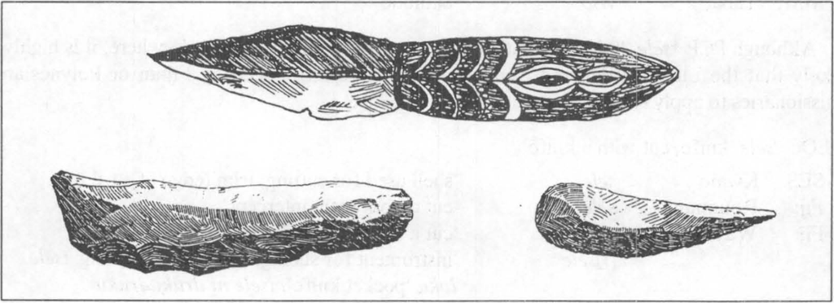

**Figure 11:** POc *nad(r)i ‘flint, obsidian, stone with a cutting edge’; POc *koto ‘obsidian knife or blade’

| **POc** |  | *nad(r)i | ‘flint, obsidian, stone with a cutting edge’ |
| --- | --- | --- | --- |
| NNG | Takia | *nad* | ‘obsidian, volcanic glass’ |
| PT | Motu | *nadi* | ‘stone’ |
| SES | Gela | *nadi* | ‘flint’ |
| SES | Bugotu | *nadi* | ‘flint’ |
| SES | Lau | *(fou) nagi* | ‘flint’ |
| SES | Arosi | *nagi* | ‘flint, obsidian’ |

| **PWOc** |  | *qa(r,R)iŋ | ‘obsidian; razor’ |
| --- | --- | --- | --- |
| NNG | Lukep | *ailiŋ* | ‘razor (traditional razor was a sharpened shell)’ |
| NNG | Gedaged | *yaliŋ* | ‘obsidian (a splinter of it serves as a razor)’ |
| NNG | Kove | *ali-ali* | ‘obsidian’ |
| PT | Duau | *kalilia* | ‘arrow’ |
| PT | Sudest | *kayina* | ‘knife’ |
| MM | Nakanai | *hali* | ‘obsidian; razor formerly made of obsidian’ |
| MM | Meramera | *ali* | ‘obsidian’ |

| **POc** |  | *koto | ‘obsidian head of spear, obsidian knife or blade; cut (across)’ |
| --- | --- | --- | --- |
| NNG | Dami | *oto* | ‘spear’ |
| NNG | Lukep | *koto* | ‘cut across grain’ |
| NNG | Wab | *kot* | ‘cut’ |
| NNG | Sissano | *ʔot* | ‘chop’ |
| MM | Tigak | *koto* | ‘cut off’ |
| MM | Ramoaaina | *koto* | ‘obsidian; used to make scars or to shave’ |
| MM | Tolai | *koto* | ‘piece of stone (obsidian) or shell used as a lance’ |
| MM | Roviana | *koto(a)* | ‘cut or trim hair, shrubs +’ |
| SES | Kwaio | *ʔoto* | ‘hit and perforate’ |
| SES | Arosi | *koto* | [V] ‘spear’ |
| SES | Arosi | *oto* | ‘arrow without barbs’ |
| NCV | Mota | *koto* | ‘nip, snap’ |
| NCV | Nguna | *koto(vi)* | ‘break, cut (a long thing); separate, away’ |
| NCV | Lonwolwol | *kote, gote* | ‘across, through’ |

A group of eastern Polynesian languages have a term for obsidian probably derived from POc *(m,mʷ)ata ‘cutting edge’ (§4.1.1).

| Pn | Rapanui | *matā* | ‘obsidian’ |
| --- | --- | --- | --- |
| Pn | Māori | *matā* | ‘obsidian, flint, quartz’ |
| Pn | Hawaiian | *mākā* | ‘kind of stone’ |

#### 4.1.4. Awl

Multi-purpose piercing tools may have been carried, fashioned from bone, perhaps a pig’s femur. These were useful for piercing shells, splitting fibres for weaving, splitting areca nuts, separating coconut meat from its shell and such daily activities. They were probably also used to pierce earlobes and the nasal septum. Green (1979:39) lists a worked pig-tusk piercing tool from the Main Reef Islands, circa 1100 B.C. Reconstructions appear primarily verbal, with a term for the instrument sometimes derivable from the verb. They include POc *puru(k), *puruk-i- ‘pierce, bore (hole)’, POc *buru ‘bore a hole, drill’; PWOc *bʷaR(i,e) ‘bore (hole)’; and PEOc *paRo ‘drill through, pierce, perforate’ (see Chapter 9, §4.2, for the cognate sets).

#### 4.1.5. Sharpening and grinding

There is evidence that all three of the basic methods for shaping stone—flaking (also called chipping), pecking and grinding—were practised in POc times (Oliver 1989: 144). We have several reconstructions for actions which include sharpening or grinding, but they may also refer to grating (foodstuffs), and at times to rasping and filing (wood and shell). Pumice, widely available in volcanic regions, was typically used for sharpening stone. Although we can reconstruct terms for the activity, the only reconstruction we have for the implement is the PCP term for a whetstone.

| **PCP** |  | *vuqa(i)ŋa | ‘whetstone, grindstone’ |
| --- | --- | --- | --- |
| Fij | Wayan | *vuaiŋō* | ‘pumice stone, pumice; used for scouring coconut-shell cups’ |
| Pn | Tongan | *fuʔo-fuʔaŋa* | ‘pumice’ |
| Pn | Samoan | *foaŋa* | ‘grindstone’ |
| Pn | Rarotongan | *ʔoaŋa* | ‘grindstone’ |
| Pn | Mangarevan | *hoaga* | ‘volcanic stone used as hone or sharpener’ |
| Pn | Māori | *hōaŋa* | ‘sandstone used in grinding stone’ |

From its form it is clear that PCP *vuqa(i)ŋa is a nominalisation. The corresponding verb occurs in Polynesian languages with somewhat altered meaning (Samoan *foa* ‘break rock or shell’, Hawaiian *hoa* ‘strike with stick or club’). Together with the WOc cognates, Iduna (PT) *fua-* ‘crush’, Motu (PT) *huari* ‘smash, as pottery’ and Tolai *puar* ‘break (cup, glass +)’ they point to POc *pu(q)a(R), *pu(q)aR-i- ‘break, as s.t. hard, smash’.

| **PAn** |  | *Sasaq | ‘whet, sharpen’ (ACD) |
| --- | --- | --- | --- |
| **POc** |  | *asa(q), *asaq-i- | ‘grate, sharpen by grating or rubbing’ |
| **POc** |  | *i-asa(q) | ‘grater; anything used to grate, grind’ (Lichtenberk 1994) |
| Adm | Loniu | *yasa(y)* | ‘sharpen (a cutting edge)’ |
| NNG | Manam | *ara* | ‘grate, sharpen, rub’ |
| NNG | Kairiru | *yas* | ‘sharpen s.t.’ |
| MM | Teop | *aha* | ‘grate (tapioca +); scrub (floor +)’ |
| MM | Teop | *(i)aha* | ‘grater (for tapioca)’ (*i-* < POc *i- INS) |
| MM | Maringe | *jaha, zaha* | ‘sharpen (knife, axe +); grate (tapioca, sweet potato)’ |
| MM | Roviana | *asa-i-* | ‘grind (very blunt axe +); grate (sweet potato, taro +)’ |
| SES | Bugotu | *(a)aha* | ‘grate, rub down (taro +) on a stone, sharpen by rubbing’ |
| SES | Lau | *sata* | ‘rub, rub down, sharpen by rubbing’ |
| SES | Arosi | *ata* | ‘scrape, rub, sharpen with rubbing’ |
| NCV | Mota | *asa* | ‘rub, wash with rubbing’ |
| SV | Kwamera | *ərəsi* | ‘scrape, grate’ |
| Mic | Carolinian | *(m)asa* | ‘(knife, axe +) blade’ |
| Mic | Ponapean | *ete* | ‘sharpen, put an edge on s.t.’ |
| Fij | Bauan | *yaða-* | ‘grate, grind, file’ |
| Fij | Bauan | *(i)yaða* | ‘grater, grindstone’ (*i-* < POc *i- INS) |
| Pn | Māori | *aha-aha* | ‘saw-like instrument of shark teeth set in a wooden mounting’ |

| **PMP** |  | *kirkir | [v] ‘file, rasp’ (Blust 1977a) |
| --- | --- | --- | --- |
| **POc** |  | *kiri | ‘file, rasp, saw’ |
| NNG | Roinji | *kiri-* | ‘bore (hole)’ |
| NNG | Manam | *kuiri-* | ‘bore (hole)’ |
| NNG | Kove | *iri* | ‘clean teeth, scrub a saucepan (both done by rubbing with sand)’ |
| PT | Iduna | *kili-li* | ‘pumice stone’ |
| PT | Motu | *iri* | [N] ‘saw’ |
| PT | Motu | *iri-ri* | ‘file’ |
| Pn | Tongan | *kili* | ‘saw, file’ |
| Pn | Tokelauan | *kili* | [v] ‘file, rasp’ |

| **POc** |  | *giri | ‘file, rasp, saw’ |
| --- | --- | --- | --- |
| NNG | Mangseng | *kir* | ‘rub, file’ |
| NNG | Mangseng | *kir(oŋa)* | [N] ‘file’ (*-oŋa* NOM) |
| SES | Gela | *gi-giri* | [N] ‘rasp; a saw’ |
| SES | Lau | *giri-giri* | ‘roughen, as a stick with notches, or in making a file’ |

cf. also:

| NNG | Takia | *riri* | ‘grate, pulverise by rubbing against s.t. rough; rasp’ |
| --- | --- | --- | --- |
| PT | Motu | *riri* | ‘grate (yams +)’ |

Both *kiri and *giri are reconstructable, the latter perhaps a verb from *N-kiri; the Polynesian reflexes are attributable to either.

The same terms may have also been used to describe the actions of smoothing and polishing. The Polynesians, in particular, were concerned to produce a fine finish to their artefacts by rubbing. Beaglehole wrote of the Tahitians, “All their [wood] work however acquires a certain neatness in the finishing for they polish every thing, even the side of a canoe or a Post of a house, with Coral sand rubbed on in the outer husk of a Cocoa nut and rays skin, which makes them very smooth and neat.” (quoted in Oliver 1974: 134). The general term for this may have been POc *quju(r) ‘rub, make smooth by rubbing’ (see Ch. 9, §2.3). In at least one language (Woleaian in Micronesia) the term for a file is the same term as that for stingray (*faiya* > PAn *paRis ‘stingray’), the skin of which serves as a fine abrasive.

## 5. Bark-cloth, clothing, body decoration

### 5.1. Bark-cloth (*tapa*)

The material used to make bark-cloth or tapa in the Pacific area is obtained mainly from various species of trees belonging to the genera *Broussonetia*, *Artocarpus*, and *Ficus*, all of which belong to the family Moraceae. Wherever *tapa* was made, the *Broussonetia papyrifera* or paper mulberry tree was used for the highest quality cloth. It is not native to the Pacific, but to eastern Asia, whence migrants carried it to Indonesia and the Pacific. The only other significant source is the *Pipturus* species, used for *tapa* particularly in Hawaii (Kooijman 1972: 1).

Bark-cloth is a significant item in Indonesia and in the eastern Oceanic region, particularly Polynesia, but also Santa Cruz, New Caledonia and Fiji. However, it does not feature strongly in the western Oceanic region. Ivens (1918: 186) wrote that although bark-cloth (*tapa*) was made in Melanesia, it never figured as an article of clothing, and its main use was to form a kind of shawl in which the baby was slung when carried from the shoulder. Ivens was probably speaking from a Solomons perspective. Kooijman (1972:446) quotes reports by Chalmers and Gill (1885) which mention bark-cloth from Collingwood Bay and the Gulf of Papua (both PT); while in the Northern Province of south-east Papua, for instance, bark-cloth is a prestigious valuable. In parts of New Britain it was used to bind the heads of young babies to achieve the desired elongated skull shape (Ann Chowning, pers.comm.). Kooijman (pp.446-453) points out that the descriptions of the manufacture of New Guinea bark-cloth and the study of the museum material indicate that, as a rule, this *tapa* is relatively thick and stiff and made from *Ficus* and Artocarpus varieties, rather than from Broussonetia. He believes that the latter was probably not used for *tapa* cloth in New Guinea. He records little mention of bark-cloth use in Micronesia, other than the wearing of *tapa* ponchos in Ponape. Yen (1973:83), in his examination of the origins of Oceanic agriculture, describes the cultivation of paper mulberry, as a pruned shrub for the production of bark for cloth, as ceasing west of the Melanesia/Polynesia border area.

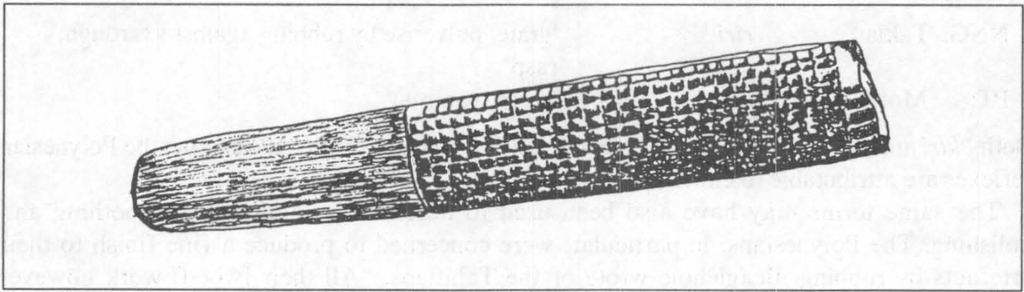

**Figure 12:** POc *ike ‘tapa beater’

Although terms can be located in WOc, none are cognate, and no POc term is reconstructable, apart from terms for the sources of raw material, POc *(m,mʷ)ase ‘wild mulberry, paper mulberry,’*Broussonetia papyrifera*’ POc *kuluR ‘breadfruit, *Artocarpus*’ (from PAn *kuluR) and POc *nunu(k) (from PMP *nunuk ‘banyan, *Ficus* spp.’) (see Plants, vol. 3).

The term *tapa*, now virtually the generic term for bark-cloth, can be reconstructed for PCP.

| **PCP** |  | *taba | ‘bark’ |
| --- | --- | --- | --- |
| Fij | Wayan | *taba* | ‘skin, bark’ |
| Pn | Tongan | *tapa* | ‘edge, rim, border, boundary’ (present meaning); ‘bark-cloth (not printed or stained)’ (old meaning; Kooijman, p. 301, from Mariner 1827)[^7] |
| Pn | Samoan | *tapa* | ‘white border of coloured bark-cloth sheet’ |
| Pn | Mangarevan | *tapa* | ‘bark-cloth’ |
| Pn | Rarotongan | *tapa* | ‘cloth made from inner bark of certain trees’ |
| Pn | Hawaiian | *kapa* | ‘bark -cloth’ |

cf. also:

| SES | Lau | *ʔaba* | ‘hand, arm, wing; leaf, frond, cloth; portion, part’ |
| --- | --- | --- | --- |
| SES | Arosi | *ʔaba* | ‘wing, limb; leaf (of banana +)’ |

Note that although the general term for bark-cloth in Tonga is *ŋatu* and in Samoa is *siapo*, the term *tapa* does exist in both places. In Tonga today it refers more generally to ‘edge, rim, border, boundary’, and in Samoa it refers to the uncoloured border of the coloured bark-cloth sheet or *siapo*. Biggs (1993) lists these as apparently unrelated homonyms. Alternatively, if we assume the original PPn meaning of *tapa to be ‘bark-cloth which was not printed or stained’, its more restricted meaning in Samoa is understandable.

A second term in Polynesia, referring both to plant and product, is widespread:

| **PPn** |  | *siapo | ‘paper-mulberry plant (*Broussonetia* sp.); bark-cloth’ (Biggs and Clark 1993) |
| --- | --- | --- | --- |
| Pn | Niuean | *hiapo* | ‘paper-mulberry plant, bark-cloth garment’ |
| Pn | Tongan | *hiapo* | ‘paper-mulberry plant’ |
| Pn | East Futunan | *siapo* | ‘bark-cloth’ |
| Pn | Samoan | *siapo* | ‘bark-cloth from paper mulberry’ |
| Pn | Marquesan | *hiapo* | ‘young banyan from which tapa is made’ |

A number of reconstructions have been made at PCP or PPn level, but the similarity of gloss indicates the likelihood of more subtleties of meaning than we have been able to identify here. They include: PCP *ŋatu ‘old or worn bark-cloth’, PCP *leu-leu ‘(old) tapa cloth’, and PPn *ŋafi-ŋafi ‘old mat or bark-cloth’ (Biggs & Clark 1993).

The only term reconstructable for the Southeast Solomons is apparently limited to the island of Malaita.

| SES | Lau | *maku* | ‘bark-cloth’ |
| --- | --- | --- | --- |
| SES | Kwaio | *maku* | ‘bark-cloth’ |
| SES | ’Are’are | *maku* | ‘cloth for married women, a fringe of string or a piece of pandanus worn in front and behind, not around the hips’ |

We have a reconstruction for the mallet used in beating *tapa* which goes back as far as PMP:

| **PMP** |  | *ike | ‘tapa-beating mallet’ |
| --- | --- | --- | --- |
| WMP | Uma | *ike* | ‘tapa-beating mallet’ (Kennedy 1934: 237) [^8] |
| **POc** |  | *ike | ‘tapa beater’ |
| SES | Sa’a | *iki (ʔoʔo)* | ‘beat the slitgongs’ (ʔoʔo ‘gong’) |
| Fij | Bauan | *ike* | ‘tapa beater’ |
| Pn | Tongan | *ike* | ‘mallet with which tutu is beaten in making tapa cloth’ |
| Pn | Samoan | *iʔe* | ‘tapa beater’ |
| Pn | East Futunan | *ike* | ‘tapa-cloth beater’ |
| Pn | Hawaiian | *iʔe* | ‘tapa beater’ |

Biggs (1993) has PPn reconstructions for the action of beating *tapa* (*tutu), and the board or anvil on which this was done (*tutua). Both terms are derived from PAn *tuqtuq ‘hammer, pound, crush’, POc *tutuk (see Ch. 9, §5.1). It is of interest that the Toradja of central Sulawesi also have a term *totua* for the wooden board on which the bark-cloth is beaten (Kennedy 1934).

### 5.2. Clothing

Over the region as a whole there is enormous variation in the degree and nature of body covering in these areas. Chowning (1991: 46) points out that “although ornaments were worn everywhere, clothes were not; for example, in parts of the Bismarck Archipelago both sexes wore nothing. In others, as Nakanai and part of Kove, only women wore clothing.” Where clothing was worn, bark-cloth was undoubtedly the most substantial wearable material. Leaves, and to a lesser extent, grass, were used to fashion skirts, aprons and G-strings.

#### 5.2.1. Loincloth

The following reconstruction of POc *malo is soundly based, although there is doubt as to whether the term can be traced back to an earlier stage. Blust (1970: 133) proposes PMP *maru ‘loincloth’, but notes the difficulty of reconciling the PMP form with the POc, with the latter having unexplained *o for expected *u and *l for expected *r. There can be little doubt that the POc term referred to bark-cloth and a garment made from that material.

| **POc** |  | *malo | ‘*Broussonetia papyrifera*, loincloth’ (Milke 1968) |
| --- | --- | --- | --- |
| NNG | Gedaged | *mal* | ‘tree, bark of which is used to make G-strings and blankets’ |
| NNG | Takia | *mal* | ‘bark-cloth’ |
| NNG | Kove | *malo* | ‘bark-cloth’ (*malo* *maloŋia* male and female breechclout-worn under skirt by women) |
| MM | Patpatar | *māl* | ‘cloth; clothing’ |
| MM | Tolai | *mal* | ‘name of small tree, *Broussonetia papyrifera*; native cloth made from bark of this tree; any kind of cloth, loincloth’ |
| MM | Teop | *maro* | ‘cloth/clothing’ |
| SES | Arosi | *maro* | ‘tree species, paper mulberry; beaten cloth of the *mara* (bark soaked in water and then beaten out, later painted in gay colours and used as a sling (*duru*) to carry a child, or a loincloth (*gaha*)… |
| NCV | Raga | *malo* | ‘men’s loin cloth’ |
| Fij | Bauan | *malo* | ‘paper mulberry; hence the native cloth made from it and the former native male dress, passed between the thighs and fastened with a girdle’ |
| Pn | Samoan | *malo* | ‘loincloth’ |
| Pn | Emae | *maro* | ‘bark-cloth’ |
| Pn | Hawaiian | *malo* | ‘loin garment’ |

Another apparent POc reconstruction for a loincloth, *sulu, with cognates in Kilivila (PT) and New Ireland as well as in the central Pacific, is relegated to PCP or PPn on the grounds that the term and garment were brought to New Guinea by Fijian and Polynesian missionaries in the nineteenth century.

The term *tipi ‘man’s loincloth’ perhaps had the generic sense ‘man’s clothing’, as its reflexes have been reinterpreted quite broadly with changes in sartorial customs.

| **POc** |  | *tipi | ‘loincloth, man’s garment’ |
| --- | --- | --- | --- |
| NNG | Numbami | *tiwi* | ‘loincloth’ |
| PT | Motu | *sihi* | ‘man’s girdle; the paper mulberry from which the girdle is made’ |
| MM | Simbo | *ti-tivi* | ‘skirt, sarong’ |
| MM | Roviana | *tivi-tivi* | ‘loincloth’ |
| SES | Gela | *tivi* | ‘sling for carrying a baby’ |
| SES | Ghari | *tivi* | ‘native loincloth for men’ |
| SES | Longgu | *ivi* | ‘sarong, lavalava’ |
| Mic | Woleaian | *sifi-sif* | ‘grass-skirt’ |

#### 5.2.2. Grass or leaf skirt

Perhaps surprisingly, there is no widely reflected item for ‘grass-skirt’ or, more accurately, ‘leaf skirt’. The set below has cognates in two primary subgroups, but, since the Admiralties and the north coast of New Guinea were connected by trading links, it may be due to borrowing.

| **POc** |  | *nai(V) | ‘woman’s grass (shredded leaf?) skirt’ |
| --- | --- | --- | --- |
| Adm | Loniu | *nay* | ‘short ornamented skirt’ |
| Adm | Nyindrou | *nay* | ‘woman’s dress’ |
| NNG | Gedaged | *nai* | ‘woman’s grass (shredded leaf?) skirt’ |
| NNG | Kairiru | *nai* | ‘woman’s grass (shredded leaf?) skirt’ |

Along much of that coast, reflexes of POc *jiRi ‘cordyline’ are used for ‘grass-skirt’:

| **POc** |  | *jiRi | ‘cordyline’ |
| --- | --- | --- | --- |
| NNG | Bariai | *(daŋasi)sid* | ‘grass-skirt’ |
| NNG | Kilenge | *na-sir* | ‘grass-skirt’ |
| NNG | Mangap | *sere(kini)* | ‘grass-skirt’ |
| NNG | Lukep | *sere(k)* | ‘grass-skirt’ |
| NNG | Malasanga | *sir* | ‘grass-skirt’ |
| NNG | Bing | *zier* | ‘grass-skirt’ |
| NNG | Mindiri | *da-dir* | ‘grass-skirt’ |
| NNG | Bilibil | *da-dir* | ‘grass-skirt’ |
| NNG | Takia | *di-dir* | ‘grass-skirt’ |

Biggs (1993) has reconstructed PPn *titi ‘skirt or kilt worn in the dance’, a term which may have the same source.

A term found only on the island of New Guinea is:

| **PNGOc** |  | *ram(i,e) | ‘grass-skirt’ |
| --- | --- | --- | --- |
| NNG | Gitua | *ram* | ‘grass-skirt’ |
| NNG | Sio | *lome* | ‘grass-skirt’ |
| NNG | Bing | *rām* | ‘grass-skirt’ |
| PT | Motu | *rami* | ‘grass-skirt’ |

POc *kaput and POc *kopu have been mentioned in relation to the wrapping of food before oven cooking (see Ch. 6, §3.7), although both are believed to have more general reference (*kaput ‘wrap up, cover’, *kopu ‘bundle up together’). It would seem that in Polynesia their reflexes have also come to apply to the covering of the body, PPn *kafu ‘spread over, cover the body (with a blanket)’ PPn *kofu ‘wrap up; clothing’.

### 5.3. Paint, smear, anoint

The practice of rubbing oil or grease on the body is known throughout the region, coconut and candlenut oil being favoured, rather than the pig fat used in the Highlands. The practice of painting red, yellow, black or white designs on the face and body with clay, lime etc. is found mainly in Melanesia. POc *lumu(k) most probably refers to oil. POc *pani would seem to cover both oiling and painting. Reflexes of POc *lumut ‘seaweed’ and *lumu(k) ‘oil’ coincide in several SES languages, so the ’Are’are term appears to be a blend of the two meanings, the idea of anointing with oil presumably introduced with Christianity.

| **PMP** |  | *lumuk | ‘(hair, skin) oily’ (ACD) |
| --- | --- | --- | --- |
| **POc** |  | *lumu(k) | ‘oil, grease’ |
| MM | Nakanai | *lomo* | ‘paint for hair and body, usually made from the oil of candlenut and red pigment’ |
| MM | Simbo | *lumu* | ‘oil, grease’ |
| MM | Roviana | *lumu-* | ‘anoint’ |
| SES | ’Are’are | *rumu* | ‘seaweed; k.o. moss on trees, used in ceremonial purification, is wrung out over the head of a newborn baby when taken into somebody’s house’ |
| SES | Arosi | *rumu* | ‘oil’ (cf. *rumu-rumu* ‘moss’) |
| Fij | Bauan | *lumu* | ‘anoint with oil’ |

cf. also:

| SES | ’Are’are | *ruma* | ‘oil, grease from pigs and coconuts, rubbed on the body to make it shiny’ |
| --- | --- | --- | --- |

In Fiji and Polynesia, reflexes of a different term, PCP *sinu ‘oil’ are used.

| **POc** |  | *pani | ‘apply oil or paint to the body’ (Chowning 1991) |
| --- | --- | --- | --- |
| NNG | Sengseng | *pan* | ‘paint designs on bark-cloth’ |
| MM | Nakanai | *vali* | ‘apply paint, feathers, or other surface adornment to the head or body’ |
| Mic | Kiribati | *bani (kamaimai)* | ‘perfumed oil’ (*kamaimai* ‘molasses of toddy’) |
| Fij | Bauan | *vani* | ‘put oil through hair with fingers’ |
| Pn | Tongan | *pani* | ‘smear, besmear, daub, or stain; rub the head with oil’ |
| Pn | Rennellese | *pani* | ‘anoint (head + with turmeric)’ |
| Pn | Samoan | *pani* | ‘dye the hair with the juice of *pani* (tree)’ |
| Pn | Māori | *pani* | ‘paint, besmear’ |

Chowning (p.48) mentions another form of body ornamentation, the blackening of teeth, evidently widespread in Melanesia as far east as the Solomons. Seligman (1910:492) describes the custom among the people of Tubetube (PT), in which fragments of a black bituminous semi-fossilised wood called *tari* are mixed into a paste with the chopped and roasted leaves of the badira tree, and held against the teeth overnight. He gives the purpose of teeth blackening as ‘a means of personal adornment and to attract the opposite sex’. A reconstructed form, *tapal, can be made for PWOc (the Sa’a term, *taha* rather than the expected *aha*, has to be considered a borrowing). Mikloucho-Maclay (1975:89) recorded in 1871 that “The natives [of Astrolabe Bay] not only blacken their faces, but also the mouth (tongue, teeth, gums, lips) with a substance which they chew.” He gives the name *taval* for this substance. Although we cannot attribute *taval* to a particular language (Mikloucho-Maclay lived in a village of Papuan speakers), it is evidence that reflexes of *tapal occur in the NNG area.

| **PWOc** |  | *tapal | ‘substance used to blacken teeth’ (Chowning 1991) |
| --- | --- | --- | --- |
| PT | Molima | *tavana* | ‘mineral substance used for blackening the teeth’ |
| MM | Tolai | *taval* | ‘baked earth for blackening teeth; the custom of blackening the teeth’ |

cf. also:

| MM | Roviana | *davala* | ‘blacken the teeth with a mixture of Terrninalia leaf, oil etc.’ |
| --- | --- | --- | --- |
| SES | Sa’a | *taha* | ‘pigment made from river rock, used in teeth-blackening’ |

A second reconstruction is PSS *ogo ‘tooth-blackening powder’ (Lau *ago*, Kwaio *ogo*). Ivens (1927 (reissued 1972):83) described the custom as practised by ‘young men or girls, who wish to give themselves airs’, although later, (1930: 121) he wrote that “it was said to preserve the teeth and prevent sore gums”.

### 5.4. Tattooing

Chowning (1991: 48) points out that tattooing in New Guinea has only limited distribution, tending to be confined to people with relatively light skin. “Where it was practised, methods ranged from the cutting of fine lines with obsidian, after which pigment was rubbed in, to the use of special implements. Darker-skinned people practised ornamental cicatrisation.” Although no POc reconstruction has been made for the activity, reflexes of POc *saRum (see §3.2.1) indicate that a tattooing needle of bat’s bone was known in both eastern and western Oceanic as well as the Admiralties. In the east Oceanic region tattooing is widespread. It was practised most extensively and reached its highest artistic development in Polynesia. A needle of bat or bird bone was tapped repetitively with a mallet, and a dye, probably of vegetable origin, rubbed into the punctured area. (Maoris used a dye made from the oily smoke of burning nut kernels. In Bellona the sap of the *ŋieemuŋii* tree—*Canarium harveyi*—was collected, allowed to set, burnt and the carbon collected and scraped into a black powder (Tickle 1977: 11)). A group of Samoic Outliers (Anuta, Luangiua, Takuu, Tikopia) use reflexes of PPn *matau ‘axe’ to refer to their tattooing chisel.

The term tattoo is Polynesian in origin:

| **PPn** |  | *tatau | [N, V] ‘tattoo’ |
| --- | --- | --- | --- |
| Pn | Tongan | *tā-tatau* | [V] ‘tattoo’ |
| Pn | Samoan | *tatau* | ‘tattooing’ |
| Pn | Rennellese | *tatau* | ‘tattooing’ |
| Pn | Rarotongan | *taa-tatau* | ‘tattooing’ |
| Pn | Tahitian | *tatau* | ‘marks or points on the human skin’ |
| Pn | Hawaiian | *kākau* | ‘tattoo; write, print on tapa’ |

A different term for tattooing is reflected in some Southeast Solomonic and Micronesian languages.

| **PEOc** |  | *make | [N, V] ‘tattoo’ |
| --- | --- | --- | --- |
| SES | ’Are’are | *make* | [V] ‘tattoo, draw’ |
| Mic | Puluwatese | *mæk* | ‘mark of any kind; person’s own tattooing’ |
| Mic | Woleaian | *make* | ‘tattoo’ |
| Mic | Carolinian | *mæk* | [N, v] ‘tattoo, mark, drawing, writing’ |

#### 5.4.1. Design

Ross (1996c) has reconstructed a verb, *noŋo ‘decorate’, used with reference to putting patterns onto pots and other articles, and for tattooing, but his supporting data are limited to three reflexes, and the reconstruction must be deemed tentative.

| **POc** |  | *noŋo | ‘decorate’ |
| --- | --- | --- | --- |
| NNG | Gitua | *noŋo* | ‘decoration in general’ |
| MM | Halia | *nono(a)* | ‘add ornamentation to edge of pot’ |
| NCV | Lewo | *nono* | ‘tattoo, picture, image, idol’ |

The kinds of designs used in tattooing, as on pottery and carved objects, and to a more limited extent on baskets and mats, are a substantial study in themselves. Ross has identified one pattern which reflects a familiar pattern in nature, the fishbone, and is found across a range of crafts.

| **POc** |  | *mʷati | ‘herringbone pattern’ |
| --- | --- | --- | --- |
| NNG | Lukep | *mos* | ‘traditional carving on paddles, canoes and wooden bowls’ |
| PT | Misima | *mati* | ‘design representing a fish’ |
| NCV | Wusi | *mac* | ‘herringbone pattern’ |

### 5.5. Ornaments

Chowning (1991: 47) describes the situation in the New Guinea area:

> Perhaps the most common everyday ornaments were necklaces of shell or animal teeth, bracelets and armbands of a variety of materials, most often worn above the elbow, and ear ornaments. Noses were usually pierced, but it is not clear how often nose ornaments were worn. The other very common ornaments were leg bands, worn below the knee, and anklets; belts and girdles; and hair ornaments, including ornamental combs. Aromatic herbs were commonly stuck onto armbands and into the hair; feathers too, unmodified or made into simple ornaments, were often stuck into the hair.

| **POc** |  | *bara | ‘plaited cane armlet’ |
| --- | --- | --- | --- |
| MM | Tolai | *(ta)bāra* | ‘armlet made from different kinds of woven or plaited grass’ |
| SES | Lau | *bara (obi)* | ‘plaited cane armlet (worn on lower arm)’ |

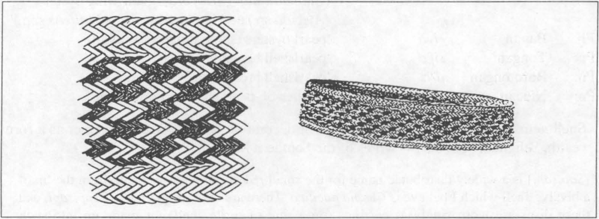

**Figure 13:** POc *bara ‘plaited cane armlet’ (from Nevermann_1934: 151)

Spriggs (1997a: 88) lists the distinctive range of shell ornaments recovered from Lapita sites such as Eloaua in the Admiralties, Balof (New Ireland) and Arawe Islands south-west of New Britain. They include Conus shell rectangular units, beads, rings and disks, *Tridacna* rings, Spondylus beads and long units and *Trochus* armrings. Reconstructions have been possible for armlets, pearlshell ornaments, ear decorations and for the act of stringing together a necklace.

| **POc** |  | *[la]lak[o] | ‘trochus shell; bracelet made from it’ |
| --- | --- | --- | --- |
| MM | Tolai | *lalai* | ‘trochus shell; armlet made from this’ |
| SES | Gela | *laɣo* | ‘cone shell’ |
| SES | Lau | *lao* | ‘cone shell’ |
| SES | Arosi | *raʔo* | ‘cone shell’ |
| NCV | Mota | *lala* | ‘univalve, top shell; bracelet made of it’ |
| NCV | Raga | *lala* | ‘top shell, *Trochus stellatus*; shell armlet, ring’ |
| Mic | Woleaian | *lax* | ‘bracelet’ |

Although these examples are in theory sufficient to justify attributing to POc *[la]lak[o] the meaning ‘bracelet’ in addition to its shell meaning (see Shellfish, vol. 3), we cannot know if both meanings were genuine inheritances in the daughter languages, or were simply associations independently made.

A similar reconstruction, referring both to a particular shell and to an ornament typically made from it, is POc *japi.

| **POc** |  | *japi | ‘k.o. bivalve (possibly gold-lipped pearlshell, *Pinctada maxima*); ornament made from this’ (Pawley 1996b) |
| --- | --- | --- | --- |
| NNG | Manam | *sai* | ‘pearlshell spoon’ |
| PT | Hula | *ravivi* | ‘clamshell’ |
| MM | Roviana | *davi* | ‘pearlshell’ |
| SES | Bugotu | *davi* | ‘gold-lipped pearlshell’ |
| SES | ’Are’are | *tafi* | ‘pearlshell; ornament made of same’ |
| SES | Arosi | *dahi* | ‘gold-lipped pearlshell’ |
| **PCP** |  | *jiva | ‘pearl oyster’ (metathesis) |
| Fij | Wayan | *civa* | ‘pearl oysters, including blacklipped pearl (*Pinctada margaritifera*), giant wing oyster (*Avicula* sp.) and hammer oysters (*Malleus* spp.)’ |
| Fij | Bauan | *civa* | ‘pearl oysters (same range as Wayan)’ |
| Pn | Tongan | *sifa* | ‘pearlshell breastplate’ |
| Pn | Rarotongan | *tiʔa* | ‘pearlshell breastplate’ |
| Pn | Niuean | *tifa* | ‘mother-of-pearl shell and ornament’ |

Shell items were evidently used not only for decoration but also strung together as a form of wealth. Seligman (1910:514) writes of the Southern Massim:[^9]:

> [*Sapisapi*] is a widely distributed name for the small red or purple discs made from the lip of a bivalve shell which I believe is *Chama pacifica*. There are various qualities of *sapisapi*, and these discs are worn singly as earrings (on a ring of turtle shell), or made up into such standard ornaments as *bagi* or the necklaces called *samakupa* at Tubetube. *Bagi* are always imported and never made locally either at Tubetube or Milne Bay, in both of which localities they constitute the most valuable portable property a man can acquire.

| **POc** |  | *(sabi-)sabi | ‘shell disc used as earring’ |
| --- | --- | --- | --- |
| PT | Tawala | *sapi-sapi* | ‘earring’ |
| SES | Arosi | *tabi-tabi* | ‘ear ornaments’ |

cf. also:

| PT | Muyuw | *lap* | ‘red discs in string of veigun (shell wealth)’ |
| --- | --- | --- | --- |
| PT | Molima | *sapi-sapi* | ‘large red shell discs sewn to belt’ |

| **PCP** |  | *sau | ‘ear pendant’ (Biggs and Clark 1993) |
| --- | --- | --- | --- |
| Fij | Rotuman | *sau* | ‘earring or ear ornament’ |
| Fij | Bauan | *sau (ni daliŋa)* | ‘earring’ (*daliŋa* ‘ear’) |
| Pn | Tongan | *hau* | ‘earring, ear ornament; nose ring, nose ornament’ |
| Pn | East Uvean | *hau* | ‘ear pendant’ |
| Pn | East Futunan | *sau* | ‘ear pendant’ |

We have not reconstructed a word for ‘necklace’, but we can reconstruct the verb used to describe stringing things together to make one.

| **PAn** |  | *CuSuR | ‘string together (beads +)’ (ACD) |
| --- | --- | --- | --- |
| **POc** |  | *tuRi | ‘sew, thread, string together’ |
| PT | Motu | *turi-* | ‘plait an armlet, sew, string fish together’ |
| PT | Magori | *turi* | [V] ‘thread, sew’ |
| PT | Lala | *kuli-kuli* | ‘sew (with thread)’ |
| MM | Vitu | *turi* | ‘sew’ |
| MM | Tolai | *tur, turu* | ‘pierce, as spear or arrow’ |
| NCV | Uripiv | *(o)turi* | ‘sew’ |
| SV | Lenakel | *til* | ‘sew, string, put on a string’ |
| SV | Kwamera | *(a)tiri* | ‘sew, weave, string beads, shuffle’ |
| Fij | Bauan | *tui* | ‘lift up with a string’ |
| Fij | Bauan | *tui-tui-(vaka)* | ‘string together’ |
| Pn | Tongan | *tui* | ‘put in, insert (hand into pocket +); thread (needle, beads +)’ |
| Pn | Tahitian | *tui* | ‘thread, string (pierced objects)’ |
| Pn | Hawaiian | *kui* | ‘string (pierced objects, as flowers in a lei, or fish); thread (beads)’ |

#### 5.5.1. Comb

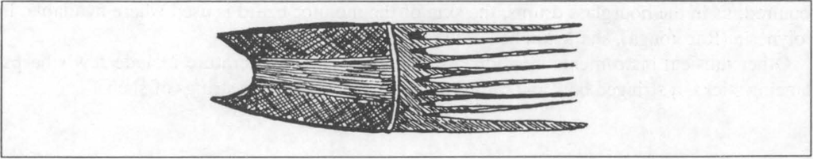

**Figure 14:** POc *saRu ‘comb’

POc inherited *saRu ‘comb’ from PMP. However, Remote Oceanic reflexes reflect *seru, and this discrepancy suggests that a borrowing must have occurred at some stage during the Oceanic dispersal.

| **PMP** |  | *saRu | ‘comb’ (Blust 1980b) |
| --- | --- | --- | --- |
| **POc** |  | *saRu | ‘comb’ (Milke 1968) |
| NNG | Manam | *saru* | ‘comb’ |
| NNG | Bing | *sar* | ‘comb’ |
| NNG | Gedaged | *saȴ* | ‘headgear made from feathers’ |
| SES | Tolo | *tsalu* | ‘comb’ |
| **PROc** |  | *seru | ‘comb’ (Milke 1968) |
| NCV | Nguna | *seru* | ‘comb’ |
| Fij | Rotuman | *seru* | ‘comb’ |
| Fij | Bauan | *(i)seru* | [N] ‘comb’ (i- < POc *i- INS) |
| Pn | Tongan | *helu* | [V] ‘comb, (bird) preen’; [N] ‘comb’ |
| Pn | Samoan | *selu* | [N, v] ‘comb’ |
| Pn | Māori | *heru(a)* | ‘comb’ |

Blust reconstructs PMP *suat ‘k.o. comb’, a root which seems to have survived as a transitive verb in POc.

| **PMP** |  | *suat | ‘k.o. comb’ (Blust 1983–84a) |
| --- | --- | --- | --- |
| **POc** |  | *su(w)at, *su(w)a[t,r]-i- | ‘comb (hair)’ |
| NNG | Bing | *sar* |  |
| NNG | Bilibil | *sari* | ‘comb (hair)’ |
| NNG | Manam | *ruati* | ‘comb (hair)’ |
| NNG | Ulau-Suain | *sur* | ‘comb (hair)’ |
| NNG | Numbami | *suwala* | ‘comb (hair)’ |
| PT | Misima | *huwal* | ‘comb (hair)’ |
| PT | Sudest | *ðuwe* | ‘comb (hair)’ |
| PT | Motu | *duari* | ‘comb (hair)’ |
| MM | Lihir | *col* | ‘comb (hair)’ |
| MM | Teop | *sua* | ‘comb (hair)’ |

## 6. Instruments of communication and music

These fall into two main categories, a) wind instruments, and b) drums. Apart from the conch shell trumpet, the wind instruments recorded in the ethnographic literature are usually of bamboo, although Blackwood (1935: 413) describes a didgeridoo-type instrument, the *mabu*, used on Buka, which is made from the trunk of a small tree. Bamboo instruments are often simply referred to by the term for bamboo. The drums are typically wooden; but occasionally lighter drums are made from larger varieties of bamboo. Where a skin head is required, as in the hourglass drums, the skin of the monitor lizard is used where available. In Polynesia (Rarotonga), sharkskin has been recorded as a drum skin.

Other musical instruments mentioned in the ethnographic literature include Jew’s-harps, dancing sticks, a stringed bow and rattles made from seed pods or strings of shells.

### 6.1. Conch shell trumpet

| **PMP** |  | *tambuRi(q) | ‘conch shell trumpet’ (ACD) |
| --- | --- | --- | --- |
| **POc** |  | *tapuRi(q) | ‘triton shell: *Charonia tritonis*, used as trumpet’ |
| Adm | Mussau | *taue* | ‘triton shell’ |
| NNG | Takia | *taur, taul* | ‘conch shell hom (used for sending messages)’ |
| NNG | Manam | *tauru* | ‘conch shell; used as a hom for calling village meetings with the councillor’ |
| MM | Sursurunga | *taur* | ‘shell type blown to send messages, triton shell’ |
| MM | Tolai | *tavur* | ‘triton shell’ |
| SES | Sa’a | *ahuri* | ‘conch shell, triton, used to summon people’ |
| SES | Arosi | *ahuri* | ‘conch shell, triton’ |
| NCV | Lonwolwol | *taviu* | ‘conch shell (and sound)’ |
| NCV | Lewo | *tapuru* | ‘shellfish *Trochus* spp.’ |
| Mic | Kiribati | *tau* | ‘triton conch, trumpet shell’ |
| Mic | Ponapean | *sewi* | ‘conch shell, trumpet’ |
| Fij | Wayan | *tavui* | ‘triton shell: Pacific or Triton’s Trumpet’ |
| Fij | Bauan | *davui* | ‘trumpet shell or triton’ |

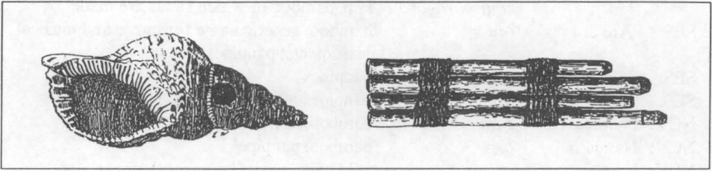

**Figure 15:** POc *tapuRi(q) ‘triton shell trumpet’ (from Nevermann_1933:218) POc *kauR ‘bamboo wind instrument’

In Polynesia the triton shell trumpet is generally known as *puu*, an onomatopaeic word which in many languages is associated with concepts of blowing.

### 6.2. Bamboo flute

| **POc** |  | *upi, *ipu | ‘blow; native flute’[^10] |
| --- | --- | --- | --- |
| PT | Kilivila | *(y)uvi* | ‘blow’ |
| PT | Motu | *ivi(likou)* | ‘a reed musical instrument, a flute’ |
| MM | Roviana | *ivu* | ‘blow, as a conch shell’ |
| MM | Roviana | *iv-ivu(ana)* | ‘a native flute’ (*-ana* NOM) |
| SES | Bugotu | *ifu* | ‘blow, of fire or panpipes; panpipes’ |
| SES | Kwaio | *ufi* | ‘play panpipes’ |
| SES | Sa’a | *uhi* | ‘blow with the mouth upon an object’ |
| SES | Arosi | *(ʔau)uhi-uhi* | ‘panpipes of bamboo’ (*uhi* ‘blow, breathe’) |
| Fij | Bauan | *uvu(ða)* | ‘blow with the mouth’ |

| **PAn** |  | *qauR | ‘bamboo sp.’ (ACD) |
| --- | --- | --- | --- |
| **POc** |  | *kauR | ‘bamboo; bamboo wind instrument’ |
| Adm | Mussau | *kauru* | ‘bamboo’ |
| NNG | Lukep | *kaur* | ‘flute: traditional musical instrument made out of bamboo (monomono); it has four notes per octave. Historically a man would play the flute when he was hungry and had nothing to eat.’ |
| NNG | Bing | *kau(mahay)* | ‘bamboo sp.; flute, long bamboo wind instrument (2.7m x 5cm)’ |
| MM | Tolai | *kaur* | ‘k. o. bamboo’ |
| MM | Tolai | *kaur goragoro* | ‘k. o. bamboo of which flutes are made’ |
| SES | ’Are’are | *ʔau* | ‘bamboo; generic name for music and musical instruments; panpipes’ |
| SES | Sa’a | *au* | ‘panpipes’ |
| SES | Arosi | *ʔau(uhi-uhi)* | ‘panpipes of bamboo’ (*uhi* ‘blow, breathe’) |
| NCV | Paamese | *e-au* | ‘bamboo; knife; slitgong fixed in ground’ |
| NCV | Namakir | *ʔo* | ‘bamboo; panpipe’ |
| NCV | Nguna | *na-au* | ‘wild cane, reed; flute, mouth organ’ |

| **POc** |  | *kopi | ‘bamboo; bamboo flute’ |
| --- | --- | --- | --- |
| PT | Gumawana | *ko-kopi* | ‘flute’ |
| Pn | Niuean | *kofe* | ‘flute’ |
| Pn | Rennellese | *kohe* | ‘bamboo’ |
| Pn | Samoan | *ʔofe* | ‘bamboo sp.’ |
| Pn | Luangiua | *ʔohe* | ‘bamboo whistle’ |

### 6.3. Hourglass or kundu drum

This relatively small drum, easily carried, is of wood, with the end covered in (lizard) skin. Chowning (1991: 59) has noted that on the north coast of New Guinea and in some parts of west New Britain the name for the instrument is suspiciously close to the word for ‘monitor lizard’ (Sengseng *pahiyo* ‘drum’, *apahiya* ‘lizard’). Drumming is produced with the hand, and typically accompanies dances. Ivens (1927 (reissued 1972): 169) reports that “a true drum of wood with skin stretched over it, such as is used in New Guinea and Torres Straits, is not found on Mala [Malaita] and Ulawa”.

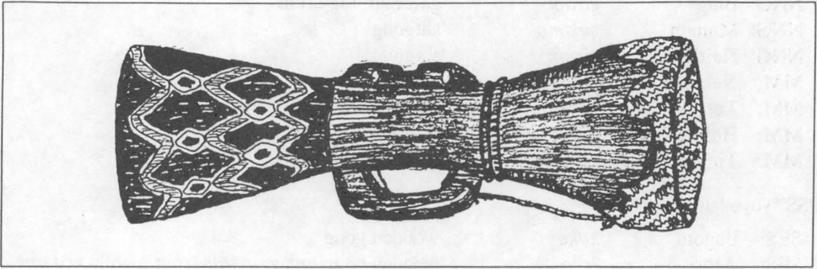

**Figure 16:** POc *kude ‘hourglass drum’

| **POc** |  | *kude | ‘hourglass drum’ |
| --- | --- | --- | --- |
| NNG | Kilenge | *kure* | ‘slitgong drum’ |
| MM | Patpatar | *kudu* | ‘drum’ (*-u* for *-e* unexpected) |
| MM | Tolai | *kudu* | ‘a long drum, the end of which is covered with the skin of an iguana’ (*-u* for *-e* unexpected) |
| MM | Vitu | *kude* | ‘(hourglass) drum’ |
| MM | Bulu | *kude* | ‘(hourglass) drum’ |
| MM | Nakanai | *kude* | ‘hourglass drum’ |
| NCV | Mota | *kore* | ‘slitgong drum’ |

The alternation in gloss between the two kinds of drum is probably due to the term for one kind being used also as a generic. Chowning (1991: 60) reports that in Kove *kure* can be used for either instrument, although there is a separate term for slitgong.

### 6.4. Slitgong

Slitgongs are carved from logs hollowed through a longitudinal slit, and beaten on one side of the lip, usually with a single heavy stick. They are often played in unison, with different logs producing different notes. The sound can carry over considerable distances and can be used to convey simple messages, summon villagers, announce a feast or the death of someone of rank and so on (Blackwood 1935: 409). They are large and heavy, often ornately carved, and will normally survive for many years. They are almost always used horizontally. In the entire Oceanic region, upright gongs, standing on their own, are found only in central Vanuatu (Crowe 1996: 147). In southern Malaita (SES), somewhat smaller wooden gongs are placed on stands and played in sets of three, loosely described as soprano, tenor and bass. These are beaten with short sections of sago bark branches, pithy and soft (Ivens 1927 (reissued 1972): 169).

Although words for musical instruments are candidates for borrowing, the fact that POc final *-t is regularly reflected or deleted throughout the cognate set below is a strong indication that these terms are not borrowed.

| **POc** |  | *garamut | ‘slitgong’ |
| --- | --- | --- | --- |
| Adm | Emira | *galamutu* | ‘slitgong’ |
| NNG | Kove | *ɣilamo* | ‘slitgong’ |
| NNG | Bing | *giram* | ‘garamut, log drum’ |
| NNG | Manam | *giramo* | ‘slitgong’ |
| NNG | Kairiru | *giram* | ‘slitgong’ |
| MM | Nakanai | *galamo* | ‘slitgong’ |
| MM | Tolai | *garamut* | ‘native log drum’ |
| MM | Halia | *garamuc* | ‘slitgong’ |
| MM | Tinputz | *kāmus* | ‘drum/slit drum’ |

| **PSS** |  | *ɣoɣo | ‘slitgong’ |
| --- | --- | --- | --- |
| SES | Bugotu | *koko* | ‘wooden gong’ |
| SES | Arosi | *ʔoʔo* | ‘wooden gong, made in sets from a hollowed tree, and used to send messages by a code so that practically any message can be sent’ |
| SES | Arosi | *barai ʔoʔo* | ‘set of slitgongs’ (includes *ʔoʔo raha* ‘bass gong’; *ʔoʔo maradaro* ‘soprano gong’; *ʔoʔo riʔi* ‘treble gong’) |

| **PCP** |  | *lali | ‘slitgong’ |
| --- | --- | --- | --- |
| Fij | Bauan | *lali* | ‘native wooden drum, beaten with two sticks’ |
| Pn | Tongan | *lali* | ‘wooden drum (Fijian style)’ |
| Pn | Samoan | *lali* | ‘middle-sized wooden gong, drum’ |
| Pn | Tuvalu | *lali* | ‘bell, wooden gong’ |

| **PCP** |  | *(v,b)asu | ‘a drum; to drum, thump’ |
| --- | --- | --- | --- |
| Fij | Bauan | *vaðu* | ‘punch with the fist’ |
| Pn | Niuean | *pahu* | ‘drum’ |
| Pn | Tongan | *pahu* | ‘thump’ |
| Pn | Rarotongan | *paʔu* | ‘drum formed from a hollowed block and covered with sharkskin’ |
| Pn | Tahitian | *pahu* | ‘drum; thumping blow’ |
| Pn | Hawaiian | *pahu* | ‘drum’ |
| Pn | Māori | *pahū* | ‘wooden gong’ |

| **PPn** |  | *nafa | ‘a wooden drum’ |
| --- | --- | --- | --- |
| Pn | Niuean | *nafa* | ‘small wooden drum shaped like a canoe, with a narrow slot on one side’ (McEwen 1970) |
| Pn | Samoan | *nafa* | ‘native drum’ |
| Pn | Tikopia | *nafa* | ‘large bowl-shaped trough’ |

### 6.5. Jew’s-harp

| **PWOc** |  | *bogo-bogo | ‘Jew’s-harp’ |
| --- | --- | --- | --- |
| NNG | Mapos Buang | *bgog* | ‘Jew’s-harp; usually made from bamboo’ |
| MM | Tinputz | *pokpoko* | ‘Jew’s-harp’ (Blackwood 1935: 413) |

## 7. Other artefacts

### 7.1. Broom

| **POc** |  | *sapu(r), *sapur-i- | ‘brush (dirt +) off (s.t.)’ (where ‘s.t.’ is the object) |
| --- | --- | --- | --- |
| Adm | Titan | *sapʷi* | ‘wipe, wipe off’ |
| NNG | Mapos Buang | *rvu* | ‘wipe, dry, clean’ |
| PT | Muyuw | *(katu)sap* | ‘brush dirt off’ |
| PT | Misima | *hapul* | ‘brush down (e.g. with coconut husk); brush; brush off’ |
| PT | Motu | *dahu* | ‘rub, wipe’ |
| MM | Bulu | *ravu* | ‘wipe’ |
| MM | Nakanai | *savul(a-taro-a)* | ‘brush away’ |
| MM | Patpatar | *sah* | ‘sweep’ |
| MM | Tolai | *avu(lar)* | [VT] ‘brush or wipe off, as dust with the hand’ |
| SES | Talise | *savu(lano)* | ‘rub’ |
| SES | Lau | *tafu* | ‘brush off, brush against’ |
| SES | Longgu | *tavuri-* | ‘flick or brush something off’ |
| Pn | Samoan | *safu* | ‘broom’ |

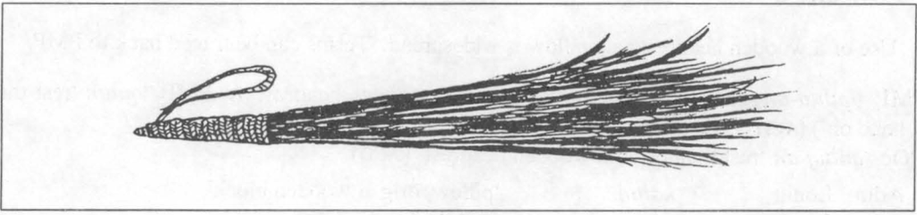

**Figure 17:** POc *salap ‘broom’

| **POc** |  | *tapi | ‘dust off, brush lightly’ |
| --- | --- | --- | --- |
| PT | Motu | *tahi-* | ‘dig out; (fowls +) scratch’ |
| PT | Minaveha | *tapi-* | ‘dust off (ashes from food +)’ |
| MM | Sursurunga | *tahi* | ‘sweep out, clean out’ |
| MM | Tolai | *tavie* | ‘a broom’ |
| Fij | Wayan | *tavi* | ‘be brushed lightly, swept, peeled’ |
| Fij | Bauan | *tavi* | ‘slap, pat, push with the hand’ |
| Pn | Tongan | *tafi* | ‘sweep’ |
| Pn | Samoan | *tafi* | ‘clear away, remove, brush off, rub off’ |
| Pn | Tikopia | *tafi* | ‘brush lightly, stroke, smear’ |
| Pn | Māori | *tahi* | ‘sweep’ |

| **POc** |  | *salap, *salap-i- | ‘sweep, broom’ |
| --- | --- | --- | --- |
| NNG | Yabem | *salep* | ‘broom, originally the fruit stem of the nipa palm’ |
| NNG | Gedaged | *salai* | ‘inflorescence of coconut’ |
| PT | Misima | *hala* | ‘sweep’ |
| SES | Lau | *ta-tala* | ‘broom made from midribs of sago palm’ |
| SES | Lau | *talafi* | ‘sweep (s.t.)’ |
| SES | ’Are’are | *tā-tara* | ‘sweep the house’ |
| SES | Sa’a | *tala* | ‘sweep the house with a bunch of leaves or grasses’ |
| SES | Arosi | *tara* | ‘rake, sweep, gather; a broom’ |
| SES | Arosi | *ta-tarahi* | ‘sweep (s.t.)’ |

cf. also:

| MM | Tolai | *are* | ‘clear away’ |
| --- | --- | --- | --- |
| SES | Sa’a | *sā-sala* | ‘be clear, not touching the ground’ |
| SES | Arosi | *ma-sara* | ‘burnt-off garden’ |
| NCV | Mota | *sara* | ‘pass, draw along, sweep, be swept away’ |
| NCV | Nguna | *sara* | ‘sweep’ |
| Fij | Wayan | *ðara* | ‘clear a garden (burn off dried vegetation) for planting’ |
| Fij | Bauan | *ðara* | ‘clear a walk of rubbish’ |
| Fij | Bauan | *ðara-ðara* | ‘cleared, clean of weeds’ |

### 7.2. Headrest

Use of a wooden headrest as a pillow is widespread. Terms can be traced back to PMP:

| **PMP** |  | *qulun-an | ‘place where one rests the head: wooden headrest’ (> PMP *qulun ‘rest the head on’) (ACD) |
| --- | --- | --- | --- |
| **POc** |  | *quluŋ-an | ‘rest the head on; wooden headrest’ (ACD) |
| Adm | Loniu | *kaluŋ* | ‘pillow, orig. a wooden block’ |
| Adm | Seimat | *ul-uluŋ* | ‘rest the head’ |
| Adm | Titan | *ul-uləuŋ* | ‘pillow, wooden neck support, anything used as a pillow’ |
| PT | Gabadi | *i-uina-na* | ‘pillow’ |
| MM | Sursurunga | *l-ulŋan* | ‘pillow’ |
| SES | Bugotu | *uluŋa* | [N] ‘pillow’; [V] ‘pillow (the head)’ |
| SES | Gela | *uluŋa* | ‘rest one’s head on; a headrest of wood, pillow (modern)’ |
| SES | Ulawa | *uluŋa* | [V] ‘pillow, serve as a pillow’ |
| NCV | Mota | *uluŋa* | ‘pillow’ |
| SV | North Tanna | *koulogo* | ‘pillow, headrest’ |
| Mic | Ponapean | *ul-ūl* | ‘pillow; small hill; use a pillow’ |
| Mic | Ponapean | *uluŋ* | [VT] ‘use as pillow’ |
| Mic | Chuukese | *wɨ̄n* | ‘pillow, headrest’ |
| Pn | Tongan | *ʔoluŋa* | ‘headrest, pillow’ |
| Pn | Niuean | *uluŋa* | ‘pillow, headrest’ |
| Pn | Hawaiian | *uluna* | ‘pillow’ |

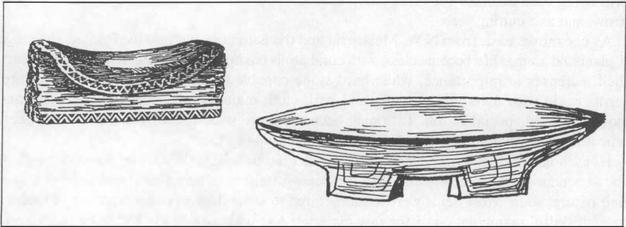

**Figure 18:** POc *quluŋ-an ‘wooden headrest’ (from Nevermann_1934:271)

| **POc** |  | *kalik | ‘native wooden pillow’ |
| --- | --- | --- | --- |
| NNG | Takia | *kalik* | ‘wooden headrest’ |
| NNG | Lukep | *kaliki* | ‘pillow: traditional pillow was made of wood with intricate carvings’ |
| Fij | Bauan | *kali* | ‘native pillow, made of wood’ |
| Pn | Tongan | *kali* | ‘native wooden pillow or headrest’ |

## 8. Conclusions

Our reconstructions are for items which draw on a range of raw materials. They include:

- vegetable products (a variety of timbers, bamboo, coconut shell, leaves, vine, cane and bark)
- stone (of variable quality, the most useful being obsidian, flint and basalt)
- coral and shell (*Tridacna*, *Trochus*, *Conus*, clam, pearlshell and others; turtle shell)
- animal products (bone, skin)
- earth products (pigments, earth, clay).

While most of these would be readily available throughout the western Oceanic region, two in particular—obsidian and clay of good, workable quality—are limited in their distribution. Although obsidian and clay pots were widely traded, cognate sets supporting reconstructions are relatively few. The potting term evidence, however, for all its limitations, shows considerable continuity of terms from PMP to POc The paucity of Oceanic terms may be due in part to the scattered nature of pot-making settlements, together with the widespread replacement in recent times of pots by tinware, but is also no doubt due to the long-term disappearance of the skill in the eastern Oceanic region. Although traces of Lapita pots have been uncovered as far east as Fiji-Tonga-Samoa, the manufacture and use of pottery was evidently abandoned in Polynesia early in the first millenium AD (Kirch 1997:68). Fiji is the most easterly place where pottery manufacture survives in the Pacific. In the Solomons, archaeologists have found few traces of pottery other than some scattered remains on Buka Island (Kirch 1997:53), and, more recently, in Marovo Lagoon, western Solomons (Peter Shepherd, pers.comm.).

Nor has reconstructing a term for obsidian been straightforward. As a glance at the glosses will show, there is considerable variation in meaning from place to place, with the obsidian term being used at times for other sharp stones, for a razor, for the head of a spear or an arrow, and as a cutting verb.

As one moves east, from N.W. Melanesia and the Solomons out into the Pacific, the range of plant and animal life becomes less, with coral atolls having the most restricted environments. Shell increases in importance, while hard stone capable of taking an edge becomes rare. Terms to do with mats and weaving and bark-cloth manufacture increase in number and show increased specialization. Tattooing becomes more widespread. These are most likely indicators of developing elaborations after the break-up of POc.

Household artefacts varied greatly in the degree to which they were manufactured. A few—coconut-shell containers and shell scrapers—would have been functional more or less in their natural state. Most items were manufactured to some degree, either with use of tools or through skilful manipulation of the raw material. Axe and adze heads had to be shaped and fitted with a handle; wooden bowls required tools that cut and shaped and gouged, smaller versions of the tools used in canoe manufacture. Mats and baskets ranged from the very simple to the intricately shaped and patterned, serving not only as domestic items but also as house walls and canoe sails. Cordage produced not only bags but also a range of fishing nets.

Pottery would seem to be the household artefact requiring the most complex stages of manufacture. There would have been little need of tools beyond paddle (POc *tapi) and anvil (POc *patu ‘stone’). However, stages would include preparation of the clay involving tempering with sand, moulding, decorating, drying, firing, and, for some, sealing with a vegetable caulking agent.[^11]: One would assume that this kind of knowledge would be accumulated over a long period of trial and error, and probably passed down as an integrated procedure. We know that in more recent times the skill of making pots was a jealously guarded trade secret, not one that could simply be copied by examining the final product.

One further point that can be made about POc artefacts is that at least some of them demonstrated a desire by their makers to produce something that was more than simply functional. Although this point is illustrated most vividly by archaeological findings dating back to POc times, particularly the early Lapita pots, the mere existence of such decorative items as earrings, arm rings and combs points to a desire for some sort of ornamentation, some kind of artistic expression.

## Notes

[^1]: We are indebted to Ann Chowning both for the many references taken from her 1991 paper ‘Proto Oceanic culture: the evidence from Melanesia’, and for her more recent comments and additions to the data offered during the preparation of this chapter.
[^2]: For a fuller account of POc pottery manufacture, see Ross (1996c).
[^3]: The pair are strikingly parallel to POc *upi/*ipu ‘blow’, and it is possible that both pairs were generated at the same time by the application of a single rule (or similar wordplay) to the pre-existing member of each pair.
[^4]: Oliver (1974: 139) describes cord making from “the flax-like *piripiri* (Cenchrus echinatus)” in Tahiti, quoting from Hendy (1927).
[^5]: Takia *-l-* is the lenis reflex of POc *-t-.
[^6]: Reconstructed on the basis of Gorontalo *pito*, Indonesian *pisau*, Buginese *piso*, all ‘knife’, and the Oceanic reflexes listed here.
[^7]: Kooijman quotes from a report by William Mariner, a young Englishman stranded in Tonga from 1806-1810, indicating that at that time the term *tapa* was used as well as the more general term *ŋatu*, the former referring to any bark-cloth “not printed or stained” (Mariner 1827, vol.2,206).
[^8]: Kennedy identified terms as ‘Toradja’ in central Sulawesi. This is now recognised as a group of around a dozen related languages. The term *ike* ‘barkcloth beater’ exists in at least one of them, Uma. Thanks are due to Phil Quick for locating relevant texts.
[^9]: Seligman’s work is an ethnography of the people who live in the region of Milne Bay, at the southeastern tip of mainland New Guinea. He does not specify language groups, but Wagawaga and Tubetube are among the languages spoken.
[^10]: Cf. POc *ubi/*ibu ‘half coconut shell used as drinking cup’ (§2.2.2). It is possible that both *ubi/*ibu and *upi/*ipu were generated at the same time by the application of a single rule (or similar wordplay) to the pre-existing member of each pair.
[^11]: See Ross (1996c) for more detail of these processes.